# Weighted analyses of SDQ trajectories following FI

# SDQ Trajectories by 3-level Food Insecurity

Total sample (i.e. unique IDs) = 2125

| Subscale | sweep | N | mean | SD | median | IQR |
| --- | --- | --- | --- | --- | --- | --- |
| SDQ_Conduct | De | 2110 | 1.605 | 1.346 | 1 | 1 |
| SDQ_Conduct | Df | 2120 | 1.455 | 1.380 | 1 | 2 |
| SDQ_Conduct | Dg | 2119 | 1.356 | 1.402 | 1 | 2 |
| SDQ_Conduct | Dh | 2116 | 1.152 | 1.367 | 1 | 2 |
| SDQ_Conduct | Di | 2094 | 1.164 | 1.455 | 1 | 2 |
| SDQ_Conduct | Dj | 2032 | 1.067 | 1.406 | 1 | 2 |
| SDQ_Hyper | De | 2110 | 3.482 | 2.262 | 3 | 3 |
| SDQ_Hyper | Df | 2120 | 3.322 | 2.348 | 3 | 4 |
| SDQ_Hyper | Dg | 2119 | 3.278 | 2.448 | 3 | 4 |
| SDQ_Hyper | Dh | 2116 | 2.843 | 2.331 | 2 | 3 |
| SDQ_Hyper | Di | 2094 | 2.773 | 2.339 | 2 | 3 |
| SDQ_Hyper | Dj | 2032 | 2.539 | 2.308 | 2 | 3 |
| SDQ_Peer | De | 2110 | 0.911 | 1.250 | 0 | 1 |
| SDQ_Peer | Df | 2120 | 0.845 | 1.278 | 0 | 1 |
| SDQ_Peer | Dg | 2119 | 1.005 | 1.437 | 0 | 1 |
| SDQ_Peer | Dh | 2116 | 1.131 | 1.599 | 1 | 2 |
| SDQ_Peer | Di | 2094 | 1.347 | 1.772 | 1 | 2 |
| SDQ_Peer | Dj | 2032 | 1.458 | 1.768 | 1 | 2 |

|  | Not at all | A lot/fair amount | A little |
| --- | --- | --- | --- |
| De | 1234 | 222 | 654 |
| Df | 1239 | 224 | 657 |
| Dg | 1238 | 224 | 657 |
| Dh | 1236 | 224 | 656 |
| Di | 1220 | 220 | 654 |
| Dj | 1182 | 212 | 638 |

## Conduct Problems and FI

### No covariates

**Estimates**

[1] “No singular fit” [1] “No convergence issues”

| REML |
| --- |
| 40627.55 |

|  | Dsdco1 |  |  |  |  |  |  |  |  |  |  |
| --- | --- | --- | --- | --- | --- | --- | --- | --- | --- | --- | --- |
| Predictors | Estimates | std. Error | std. Beta | standardized std. Error | CI | standardized CI | Statistic | std. Statistic | p | std. p | df |
| (Intercept) | 1.17 | 0.03 | -0.20 | 0.02 | 1.10 – 1.23 | -0.25 – -0.16 | 34.16 | -8.96 | **<0.001** | **<0.001** | 12578.00 |
| age cent | -0.05 | 0.00 | -0.11 | 0.01 | -0.06 – -0.04 | -0.13 – -0.09 | -10.16 | -10.16 | **<0.001** | **<0.001** | 12578.00 |
| MeFaff3lvl [A lot/fair amount] | 0.58 | 0.08 | 0.38 | 0.06 | 0.41 – 0.74 | 0.27 – 0.49 | 6.86 | 6.86 | **<0.001** | **<0.001** | 12578.00 |
| MeFaff3lvl [A little] | 0.13 | 0.06 | 0.09 | 0.04 | 0.02 – 0.24 | 0.01 – 0.16 | 2.26 | 2.27 | **0.024** | **0.024** | 12578.00 |
| age cent^2 | 0.00 | 0.00 | 0.02 | 0.01 | 0.00 – 0.00 | 0.00 – 0.04 | 2.24 | 2.24 | **0.025** | **0.025** | 12578.00 |
| age cent × MeFaff3lvl [A lot/fair amount] | -0.00 | 0.01 | -0.00 | 0.03 | -0.02 – 0.02 | -0.06 – 0.05 | -0.16 | -0.16 | 0.875 | 0.872 | 12578.00 |
| age cent × MeFaff3lvl [A little] | -0.01 | 0.01 | -0.03 | 0.02 | -0.03 – 0.00 | -0.07 – 0.01 | -1.59 | -1.60 | 0.112 | 0.110 | 12578.00 |
| MeFaff3lvl [A lot/fair amount] × age cent^2 | 0.00 | 0.00 | 0.02 | 0.02 | -0.00 – 0.01 | -0.02 – 0.06 | 0.91 | 0.91 | 0.361 | 0.361 | 12578.00 |
| MeFaff3lvl [A little] × age cent^2 | 0.00 | 0.00 | 0.04 | 0.02 | 0.00 – 0.01 | 0.01 – 0.07 | 2.30 | 2.30 | **0.022** | **0.022** | 12578.00 |
| Random Effects |  |  |  |  |  |  |  |  |  |  |  |
| σ<sup>2</sup> | 0.81 |  |  |  |  |  |  |  |  |  |  |
| τ<sub>00</sub> <sub>Idnumber</sub> | 1.02 |  |  |  |  |  |  |  |  |  |  |
| τ<sub>11</sub> <sub>Idnumber.age.cent</sub> | 0.01 |  |  |  |  |  |  |  |  |  |  |
| ρ<sub>01</sub> <sub>Idnumber</sub> | 0.13 |  |  |  |  |  |  |  |  |  |  |
| ICC | 0.59 |  |  |  |  |  |  |  |  |  |  |
| N <sub>Idnumber</sub> | 2125 |  |  |  |  |  |  |  |  |  |  |
| Observations | 12591 |  |  |  |  |  |  |  |  |  |  |
| Marginal R<sup>2</sup> / Conditional R<sup>2</sup> | 0.032 / 0.608 |  |  |  |  |  |  |  |  |  |  |

**Contrasts**

| Age | contrast | null.value | estimate | std.error | df | statistic | p.value |
| --- | --- | --- | --- | --- | --- | --- | --- |
| 4.844 | A little vs Not at all | 0 | 0.274 | 0.064 | 2724.903 | 4.288 | 0.000 |
| 4.844 | A lot/fair amount vs Not at all | 0 | 0.634 | 0.094 | 2429.480 | 6.777 | 0.000 |
| 4.844 | A lot/fair amount vs A little | 0 | 0.360 | 0.100 | 2440.108 | 3.604 | 0.000 |
| 7.863 | A little vs Not at all | 0 | 0.157 | 0.056 | 2681.476 | 2.826 | 0.005 |
| 7.863 | A lot/fair amount vs Not at all | 0 | 0.586 | 0.082 | 2470.859 | 7.156 | 0.000 |
| 7.863 | A lot/fair amount vs A little | 0 | 0.429 | 0.087 | 2478.123 | 4.914 | 0.000 |
| 14.609 | A little vs Not at all | 0 | 0.189 | 0.074 | 2822.998 | 2.543 | 0.011 |
| 14.609 | A lot/fair amount vs Not at all | 0 | 0.638 | 0.109 | 2537.640 | 5.860 | 0.000 |
| 14.609 | A lot/fair amount vs A little | 0 | 0.449 | 0.116 | 2541.922 | 3.869 | 0.000 |

**Plot**

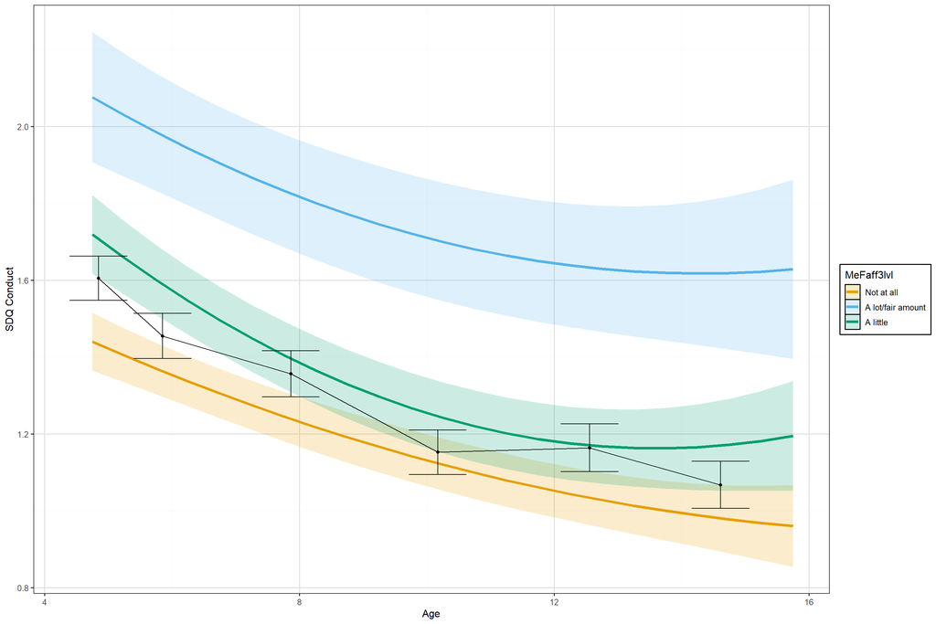

### Covariates sex and income

**Estimates**

[1] “No singular fit” [1] “No convergence issues”

| REML |
| --- |
| 40556.28 |

|  | Dsdco1 |  |  |  |  |  |  |  |  |  |  |
| --- | --- | --- | --- | --- | --- | --- | --- | --- | --- | --- | --- |
| Predictors | Estimates | std. Error | std. Beta | standardized std. Error | CI | standardized CI | Statistic | std. Statistic | p | std. p | df |
| (Intercept) | 1.07 | 0.06 | -0.27 | 0.04 | 0.95 – 1.19 | -0.34 – -0.19 | 17.56 | -6.58 | **<0.001** | **<0.001** | 12573.00 |
| age cent | -0.05 | 0.00 | -0.11 | 0.01 | -0.06 – -0.04 | -0.13 – -0.09 | -10.10 | -10.10 | **<0.001** | **<0.001** | 12573.00 |
| MeFaff3lvl [A lot/fair amount] | 0.38 | 0.09 | 0.25 | 0.06 | 0.22 – 0.55 | 0.14 – 0.37 | 4.48 | 4.48 | **<0.001** | **<0.001** | 12573.00 |
| MeFaff3lvl [A little] | 0.08 | 0.06 | 0.05 | 0.04 | -0.04 – 0.19 | -0.02 – 0.12 | 1.32 | 1.32 | 0.187 | 0.187 | 12573.00 |
| age cent^2 | 0.00 | 0.00 | 0.02 | 0.01 | 0.00 – 0.00 | 0.00 – 0.04 | 2.24 | 2.24 | **0.025** | **0.025** | 12573.00 |
| Sex [F] | -0.18 | 0.05 | -0.12 | 0.03 | -0.27 – -0.09 | -0.18 – -0.06 | -4.00 | -4.00 | **<0.001** | **<0.001** | 12573.00 |
| DeEqv5 [1] | 0.67 | 0.08 | 0.44 | 0.05 | 0.51 – 0.83 | 0.34 – 0.55 | 8.09 | 8.09 | **<0.001** | **<0.001** | 12573.00 |
| DeEqv5 [2] | 0.30 | 0.07 | 0.20 | 0.05 | 0.15 – 0.44 | 0.10 – 0.29 | 4.04 | 4.04 | **<0.001** | **<0.001** | 12573.00 |
| DeEqv5 [3] | 0.16 | 0.08 | 0.10 | 0.05 | 0.01 – 0.31 | 0.00 – 0.20 | 2.06 | 2.06 | **0.040** | **0.040** | 12573.00 |
| DeEqv5 [4] | 0.12 | 0.07 | 0.08 | 0.05 | -0.02 – 0.25 | -0.02 – 0.17 | 1.63 | 1.63 | 0.102 | 0.102 | 12573.00 |
| age cent × MeFaff3lvl [A lot/fair amount] | -0.00 | 0.01 | -0.00 | 0.03 | -0.02 – 0.02 | -0.06 – 0.05 | -0.15 | -0.15 | 0.882 | 0.879 | 12573.00 |
| age cent × MeFaff3lvl [A little] | -0.01 | 0.01 | -0.03 | 0.02 | -0.03 – 0.00 | -0.07 – 0.01 | -1.59 | -1.60 | 0.112 | 0.110 | 12573.00 |
| MeFaff3lvl [A lot/fair amount] × age cent^2 | 0.00 | 0.00 | 0.02 | 0.02 | -0.00 – 0.01 | -0.02 – 0.06 | 0.91 | 0.91 | 0.362 | 0.362 | 12573.00 |
| MeFaff3lvl [A little] × age cent^2 | 0.00 | 0.00 | 0.04 | 0.02 | 0.00 – 0.01 | 0.01 – 0.07 | 2.29 | 2.29 | **0.022** | **0.022** | 12573.00 |
| Random Effects |  |  |  |  |  |  |  |  |  |  |  |
| σ<sup>2</sup> | 0.81 |  |  |  |  |  |  |  |  |  |  |
| τ<sub>00</sub> <sub>Idnumber</sub> | 0.97 |  |  |  |  |  |  |  |  |  |  |
| τ<sub>11</sub> <sub>Idnumber.age.cent</sub> | 0.01 |  |  |  |  |  |  |  |  |  |  |
| ρ<sub>01</sub> <sub>Idnumber</sub> | 0.13 |  |  |  |  |  |  |  |  |  |  |
| ICC | 0.58 |  |  |  |  |  |  |  |  |  |  |
| N <sub>Idnumber</sub> | 2125 |  |  |  |  |  |  |  |  |  |  |
| Observations | 12591 |  |  |  |  |  |  |  |  |  |  |
| Marginal R<sup>2</sup> / Conditional R<sup>2</sup> | 0.055 / 0.608 |  |  |  |  |  |  |  |  |  |  |

**Plot**

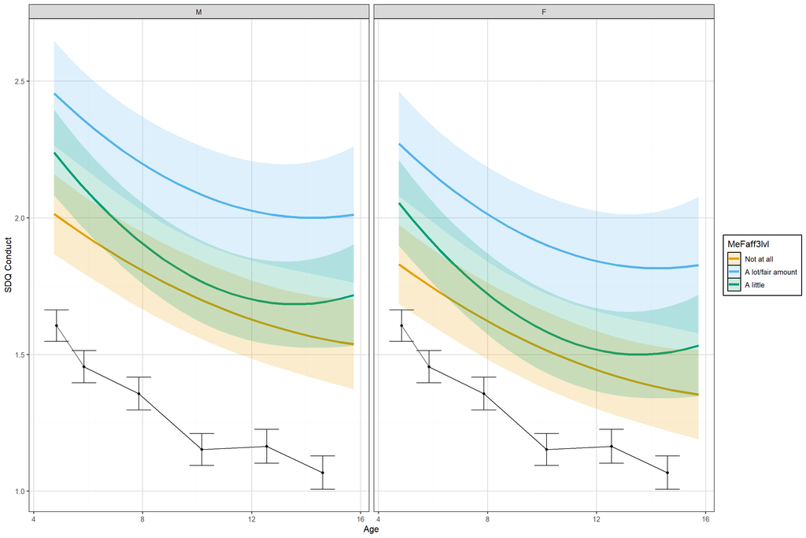

### Covariates sex, income, maternal MH

**Estimates**

[1] “No singular fit” [1] “No convergence issues”

| REML |
| --- |
| 40302.61 |

|  | Dsdco1 |  |  |  |  |  |  |  |  |  |  |
| --- | --- | --- | --- | --- | --- | --- | --- | --- | --- | --- | --- |
| Predictors | Estimates | std. Error | std. Beta | standardized std. Error | CI | standardized CI | Statistic | std. Statistic | p | std. p | df |
| (Intercept) | 1.13 | 0.06 | -0.22 | 0.04 | 1.02 – 1.25 | -0.30 – -0.14 | 19.04 | -5.59 | **<0.001** | **<0.001** | 12537.00 |
| age cent | -0.05 | 0.00 | -0.11 | 0.01 | -0.06 – -0.04 | -0.13 – -0.09 | -10.10 | -10.11 | **<0.001** | **<0.001** | 12537.00 |
| MeFaff3lvl [A lot/fair amount] | 0.27 | 0.08 | 0.18 | 0.06 | 0.10 – 0.43 | 0.07 – 0.29 | 3.15 | 3.15 | **0.002** | **0.002** | 12537.00 |
| MeFaff3lvl [A little] | 0.02 | 0.06 | 0.01 | 0.04 | -0.09 – 0.13 | -0.06 – 0.08 | 0.31 | 0.31 | 0.758 | 0.755 | 12537.00 |
| age cent^2 | 0.00 | 0.00 | 0.02 | 0.01 | 0.00 – 0.00 | 0.00 – 0.04 | 2.23 | 2.23 | **0.025** | **0.025** | 12537.00 |
| Sex [F] | -0.17 | 0.04 | -0.11 | 0.03 | -0.26 – -0.08 | -0.17 – -0.05 | -3.76 | -3.76 | **<0.001** | **<0.001** | 12537.00 |
| DeEqv5 [1] | 0.53 | 0.08 | 0.36 | 0.05 | 0.38 – 0.69 | 0.25 – 0.46 | 6.59 | 6.59 | **<0.001** | **<0.001** | 12537.00 |
| DeEqv5 [2] | 0.23 | 0.07 | 0.15 | 0.05 | 0.09 – 0.37 | 0.06 – 0.25 | 3.22 | 3.22 | **0.001** | **0.001** | 12537.00 |
| DeEqv5 [3] | 0.13 | 0.07 | 0.08 | 0.05 | -0.02 – 0.27 | -0.01 – 0.18 | 1.71 | 1.71 | 0.088 | 0.088 | 12537.00 |
| DeEqv5 [4] | 0.10 | 0.07 | 0.06 | 0.05 | -0.04 – 0.23 | -0.03 – 0.15 | 1.40 | 1.40 | 0.161 | 0.161 | 12537.00 |
| DeSf12mn | -0.25 | 0.02 | -0.16 | 0.02 | -0.29 – -0.20 | -0.19 – -0.13 | -10.84 | -10.84 | **<0.001** | **<0.001** | 12537.00 |
| age cent × MeFaff3lvl [A lot/fair amount] | -0.00 | 0.01 | -0.00 | 0.03 | -0.02 – 0.02 | -0.05 – 0.05 | -0.07 | -0.07 | 0.946 | 0.942 | 12537.00 |
| age cent × MeFaff3lvl [A little] | -0.01 | 0.01 | -0.03 | 0.02 | -0.03 – 0.00 | -0.07 – 0.01 | -1.55 | -1.57 | 0.121 | 0.117 | 12537.00 |
| MeFaff3lvl [A lot/fair amount] × age cent^2 | 0.00 | 0.00 | 0.02 | 0.02 | -0.00 – 0.01 | -0.02 – 0.06 | 0.86 | 0.86 | 0.388 | 0.388 | 12537.00 |
| MeFaff3lvl [A little] × age cent^2 | 0.00 | 0.00 | 0.04 | 0.02 | 0.00 – 0.01 | 0.01 – 0.07 | 2.46 | 2.46 | **0.014** | **0.014** | 12537.00 |
| Random Effects |  |  |  |  |  |  |  |  |  |  |  |
| σ<sup>2</sup> | 0.81 |  |  |  |  |  |  |  |  |  |  |
| τ<sub>00</sub> <sub>Idnumber</sub> | 0.91 |  |  |  |  |  |  |  |  |  |  |
| τ<sub>11</sub> <sub>Idnumber.age.cent</sub> | 0.01 |  |  |  |  |  |  |  |  |  |  |
| ρ<sub>01</sub> <sub>Idnumber</sub> | 0.17 |  |  |  |  |  |  |  |  |  |  |
| ICC | 0.57 |  |  |  |  |  |  |  |  |  |  |
| N <sub>Idnumber</sub> | 2118 |  |  |  |  |  |  |  |  |  |  |
| Observations | 12556 |  |  |  |  |  |  |  |  |  |  |
| Marginal R<sup>2</sup> / Conditional R<sup>2</sup> | 0.081 / 0.605 |  |  |  |  |  |  |  |  |  |  |

**Plot**

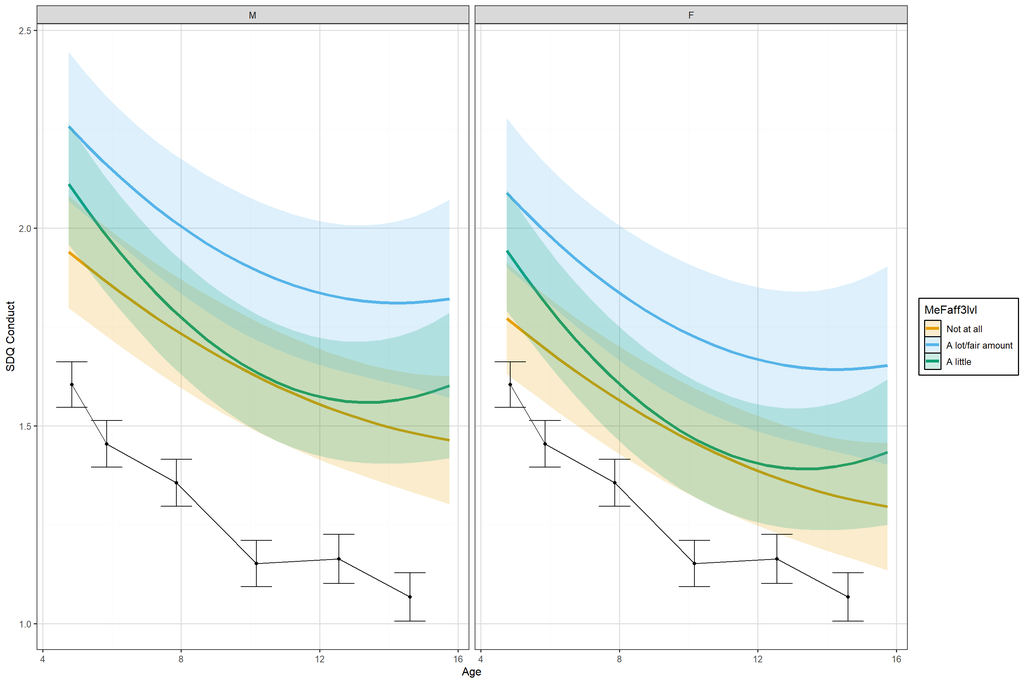

### Covariates sex, income, maternal MH, SIMD

**Estimates**

[1] “No singular fit” [1] “No convergence issues”

| REML |
| --- |
| 40294.18 |

|  | Dsdco1 |  |  |  |  |  |  |  |  |  |  |
| --- | --- | --- | --- | --- | --- | --- | --- | --- | --- | --- | --- |
| Predictors | Estimates | std. Error | std. Beta | standardized std. Error | CI | standardized CI | Statistic | std. Statistic | p | std. p | df |
| (Intercept) | 1.42 | 0.09 | -0.03 | 0.06 | 1.24 – 1.59 | -0.15 – 0.09 | 15.56 | -0.55 | **<0.001** | 0.586 | 12533.00 |
| age cent | -0.05 | 0.00 | -0.11 | 0.01 | -0.06 – -0.04 | -0.13 – -0.09 | -10.08 | -10.09 | **<0.001** | **<0.001** | 12533.00 |
| MeFaff3lvl [A lot/fair amount] | 0.26 | 0.08 | 0.17 | 0.06 | 0.09 – 0.42 | 0.06 – 0.28 | 3.04 | 3.04 | **0.002** | **0.002** | 12533.00 |
| MeFaff3lvl [A little] | 0.02 | 0.06 | 0.01 | 0.04 | -0.09 – 0.13 | -0.06 – 0.09 | 0.37 | 0.38 | 0.708 | 0.706 | 12533.00 |
| age cent^2 | 0.00 | 0.00 | 0.02 | 0.01 | 0.00 – 0.00 | 0.00 – 0.04 | 2.24 | 2.24 | **0.025** | **0.025** | 12533.00 |
| Sex [F] | -0.18 | 0.04 | -0.12 | 0.03 | -0.26 – -0.09 | -0.18 – -0.06 | -3.93 | -3.93 | **<0.001** | **<0.001** | 12533.00 |
| DeEqv5 [1] | 0.41 | 0.09 | 0.27 | 0.06 | 0.24 – 0.58 | 0.16 – 0.39 | 4.82 | 4.82 | **<0.001** | **<0.001** | 12533.00 |
| DeEqv5 [2] | 0.14 | 0.08 | 0.09 | 0.05 | -0.01 – 0.29 | -0.00 – 0.19 | 1.88 | 1.88 | 0.060 | 0.060 | 12533.00 |
| DeEqv5 [3] | 0.07 | 0.08 | 0.04 | 0.05 | -0.08 – 0.21 | -0.05 – 0.14 | 0.89 | 0.89 | 0.374 | 0.374 | 12533.00 |
| DeEqv5 [4] | 0.07 | 0.07 | 0.05 | 0.05 | -0.06 – 0.21 | -0.04 – 0.14 | 1.06 | 1.06 | 0.288 | 0.288 | 12533.00 |
| DeSf12mn | -0.24 | 0.02 | -0.16 | 0.02 | -0.29 – -0.20 | -0.19 – -0.13 | -10.58 | -10.58 | **<0.001** | **<0.001** | 12533.00 |
| ALeSNim2 [1] | -0.33 | 0.08 | -0.22 | 0.05 | -0.49 – -0.17 | -0.33 – -0.11 | -4.04 | -4.04 | **<0.001** | **<0.001** | 12533.00 |
| ALeSNim2 [2] | -0.33 | 0.08 | -0.22 | 0.05 | -0.48 – -0.17 | -0.32 – -0.12 | -4.17 | -4.17 | **<0.001** | **<0.001** | 12533.00 |
| ALeSNim2 [3] | -0.15 | 0.08 | -0.10 | 0.05 | -0.31 – 0.00 | -0.21 – 0.00 | -1.93 | -1.93 | 0.054 | 0.054 | 12533.00 |
| ALeSNim2 [4] | -0.18 | 0.08 | -0.12 | 0.05 | -0.35 – -0.02 | -0.23 – -0.02 | -2.25 | -2.25 | **0.024** | **0.024** | 12533.00 |
| age cent × MeFaff3lvl [A lot/fair amount] | -0.00 | 0.01 | -0.00 | 0.03 | -0.02 – 0.02 | -0.05 – 0.05 | -0.06 | -0.07 | 0.950 | 0.946 | 12533.00 |
| age cent × MeFaff3lvl [A little] | -0.01 | 0.01 | -0.03 | 0.02 | -0.03 – 0.00 | -0.07 – 0.01 | -1.55 | -1.57 | 0.121 | 0.117 | 12533.00 |
| MeFaff3lvl [A lot/fair amount] × age cent^2 | 0.00 | 0.00 | 0.02 | 0.02 | -0.00 – 0.01 | -0.02 – 0.06 | 0.86 | 0.86 | 0.390 | 0.390 | 12533.00 |
| MeFaff3lvl [A little] × age cent^2 | 0.00 | 0.00 | 0.04 | 0.02 | 0.00 – 0.01 | 0.01 – 0.07 | 2.46 | 2.46 | **0.014** | **0.014** | 12533.00 |
| Random Effects |  |  |  |  |  |  |  |  |  |  |  |
| σ<sup>2</sup> | 0.81 |  |  |  |  |  |  |  |  |  |  |
| τ<sub>00</sub> <sub>Idnumber</sub> | 0.90 |  |  |  |  |  |  |  |  |  |  |
| τ<sub>11</sub> <sub>Idnumber.age.cent</sub> | 0.01 |  |  |  |  |  |  |  |  |  |  |
| ρ<sub>01</sub> <sub>Idnumber</sub> | 0.17 |  |  |  |  |  |  |  |  |  |  |
| ICC | 0.57 |  |  |  |  |  |  |  |  |  |  |
| N <sub>Idnumber</sub> | 2118 |  |  |  |  |  |  |  |  |  |  |
| Observations | 12556 |  |  |  |  |  |  |  |  |  |  |
| Marginal R<sup>2</sup> / Conditional R<sup>2</sup> | 0.087 / 0.606 |  |  |  |  |  |  |  |  |  |  |

**Contrasts**

| Age | contrast | null.value | estimate | std.error | df | statistic | p.value |
| --- | --- | --- | --- | --- | --- | --- | --- |
| 4.844 | A little vs Not at all | 0 | 0.170 | 0.062 | 2769.984 | 2.754 | 0.006 |
| 4.844 | A lot/fair amount vs Not at all | 0 | 0.305 | 0.093 | 2496.544 | 3.286 | 0.001 |
| 4.844 | A lot/fair amount vs A little | 0 | 0.135 | 0.097 | 2470.749 | 1.387 | 0.166 |
| 7.863 | A little vs Not at all | 0 | 0.048 | 0.054 | 2707.524 | 0.897 | 0.370 |
| 7.863 | A lot/fair amount vs Not at all | 0 | 0.263 | 0.082 | 2462.931 | 3.209 | 0.001 |
| 7.863 | A lot/fair amount vs A little | 0 | 0.214 | 0.085 | 2482.948 | 2.521 | 0.012 |
| 14.609 | A little vs Not at all | 0 | 0.091 | 0.074 | 2855.465 | 1.234 | 0.217 |
| 14.609 | A lot/fair amount vs Not at all | 0 | 0.318 | 0.110 | 2647.624 | 2.886 | 0.004 |
| 14.609 | A lot/fair amount vs A little | 0 | 0.227 | 0.116 | 2590.321 | 1.961 | 0.050 |

**Plot: lowest level covariates**

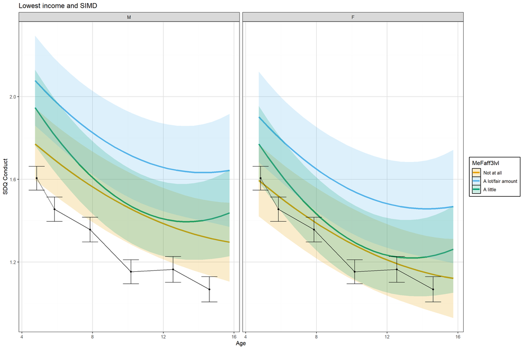

**Plot: Highest level covariates**

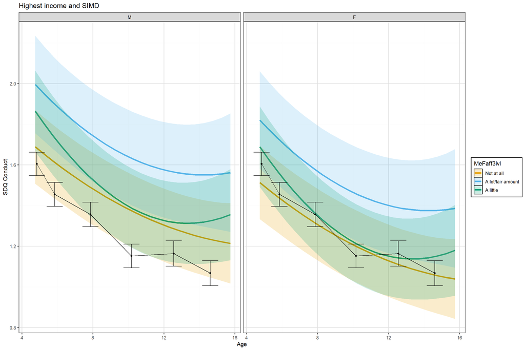

## Emotional Problems and FI

### No covariates

**Estimates**

[1] “No singular fit” [1] “No convergence issues”

| REML |
| --- |
| 46997.88 |

|  | Dsdem1 |  |  |  |  |  |  |  |  |  |  |
| --- | --- | --- | --- | --- | --- | --- | --- | --- | --- | --- | --- |
| Predictors | Estimates | std. Error | std. Beta | standardized std. Error | CI | standardized CI | Statistic | std. Statistic | p | std. p | df |
| (Intercept) | 1.35 | 0.04 | -0.16 | 0.02 | 1.27 – 1.43 | -0.20 – -0.12 | 31.57 | -7.24 | **<0.001** | **<0.001** | 12575.00 |
| age cent | 0.11 | 0.01 | 0.20 | 0.02 | 0.09 – 0.14 | 0.15 – 0.24 | 8.68 | 8.69 | **<0.001** | **<0.001** | 12575.00 |
| MeFaff3lvl [A lot/fair amount] | 0.76 | 0.11 | 0.39 | 0.05 | 0.55 – 0.97 | 0.29 – 0.50 | 7.23 | 7.23 | **<0.001** | **<0.001** | 12575.00 |
| MeFaff3lvl [A little] | 0.29 | 0.07 | 0.15 | 0.04 | 0.15 – 0.43 | 0.08 – 0.22 | 4.07 | 4.07 | **<0.001** | **<0.001** | 12575.00 |
| age cent^2 | 0.00 | 0.00 | 0.01 | 0.01 | -0.00 – 0.00 | -0.01 – 0.03 | 0.65 | 0.69 | 0.514 | 0.493 | 12575.00 |
| age cent^3 | -0.00 | 0.00 | -0.05 | 0.01 | -0.00 – -0.00 | -0.07 – -0.02 | -3.77 | -3.77 | **<0.001** | **<0.001** | 12575.00 |
| age cent × MeFaff3lvl [A lot/fair amount] | -0.03 | 0.03 | -0.05 | 0.05 | -0.09 – 0.03 | -0.15 – 0.05 | -0.95 | -0.95 | 0.342 | 0.344 | 12575.00 |
| age cent × MeFaff3lvl [A little] | -0.01 | 0.02 | -0.01 | 0.04 | -0.05 – 0.03 | -0.09 – 0.06 | -0.37 | -0.37 | 0.711 | 0.713 | 12575.00 |
| MeFaff3lvl [A lot/fair amount] × age cent^2 | -0.01 | 0.00 | -0.04 | 0.02 | -0.01 – 0.00 | -0.09 – 0.01 | -1.58 | -1.59 | 0.114 | 0.113 | 12575.00 |
| MeFaff3lvl [A little] × age cent^2 | -0.00 | 0.00 | -0.02 | 0.02 | -0.01 – 0.00 | -0.06 – 0.01 | -1.25 | -1.25 | 0.212 | 0.211 | 12575.00 |
| MeFaff3lvl [A lot/fair amount] × age cent^3 | 0.00 | 0.00 | 0.04 | 0.03 | -0.00 – 0.00 | -0.01 – 0.10 | 1.48 | 1.48 | 0.138 | 0.138 | 12575.00 |
| MeFaff3lvl [A little] × age cent^3 | 0.00 | 0.00 | 0.02 | 0.02 | -0.00 – 0.00 | -0.02 – 0.07 | 1.14 | 1.14 | 0.254 | 0.254 | 12575.00 |
| Random Effects |  |  |  |  |  |  |  |  |  |  |  |
| σ<sup>2</sup> | 1.37 |  |  |  |  |  |  |  |  |  |  |
| τ<sub>00</sub> <sub>Idnumber</sub> | 1.52 |  |  |  |  |  |  |  |  |  |  |
| τ<sub>11</sub> <sub>Idnumber.age.cent</sub> | 0.03 |  |  |  |  |  |  |  |  |  |  |
| ρ<sub>01</sub> <sub>Idnumber</sub> | 0.49 |  |  |  |  |  |  |  |  |  |  |
| ICC | 0.58 |  |  |  |  |  |  |  |  |  |  |
| N <sub>Idnumber</sub> | 2125 |  |  |  |  |  |  |  |  |  |  |
| Observations | 12591 |  |  |  |  |  |  |  |  |  |  |
| Marginal R<sup>2</sup> / Conditional R<sup>2</sup> | 0.034 / 0.590 |  |  |  |  |  |  |  |  |  |  |

**Contrasts**

| Age | contrast | null.value | estimate | std.error | df | statistic | p.value |
| --- | --- | --- | --- | --- | --- | --- | --- |
| 4.844 | A little vs Not at all | 0 | 0.160 | 0.075 | 3700.106 | 2.144 | 0.032 |
| 4.844 | A lot/fair amount vs Not at all | 0 | 0.593 | 0.108 | 3126.891 | 5.510 | 0.000 |
| 4.844 | A lot/fair amount vs A little | 0 | 0.433 | 0.115 | 3145.301 | 3.765 | 0.000 |
| 7.863 | A little vs Not at all | 0 | 0.294 | 0.071 | 3934.092 | 4.125 | 0.000 |
| 7.863 | A lot/fair amount vs Not at all | 0 | 0.783 | 0.103 | 3446.036 | 7.573 | 0.000 |
| 7.863 | A lot/fair amount vs A little | 0 | 0.489 | 0.110 | 3461.679 | 4.435 | 0.000 |
| 14.609 | A little vs Not at all | 0 | 0.316 | 0.107 | 2788.781 | 2.959 | 0.003 |
| 14.609 | A lot/fair amount vs Not at all | 0 | 0.731 | 0.157 | 2525.138 | 4.667 | 0.000 |
| 14.609 | A lot/fair amount vs A little | 0 | 0.415 | 0.167 | 2530.816 | 2.487 | 0.013 |

**Plot**

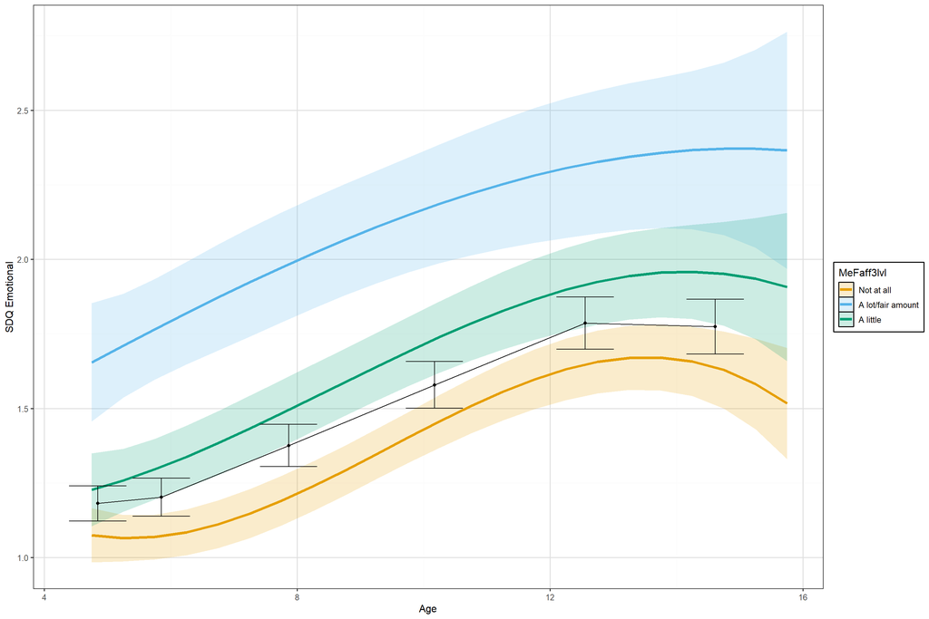

### Covariates sex and income

**Estimates**

[1] “No singular fit” [1] “No convergence issues”

| REML |
| --- |
| 46974.65 |

|  | Dsdem1 |  |  |  |  |  |  |  |  |  |  |
| --- | --- | --- | --- | --- | --- | --- | --- | --- | --- | --- | --- |
| Predictors | Estimates | std. Error | std. Beta | standardized std. Error | CI | standardized CI | Statistic | std. Statistic | p | std. p | df |
| (Intercept) | 1.24 | 0.07 | -0.22 | 0.04 | 1.10 – 1.39 | -0.29 – -0.14 | 16.88 | -5.68 | **<0.001** | **<0.001** | 12570.00 |
| age cent | 0.11 | 0.01 | 0.20 | 0.02 | 0.09 – 0.14 | 0.16 – 0.25 | 8.74 | 8.75 | **<0.001** | **<0.001** | 12570.00 |
| MeFaff3lvl [A lot/fair amount] | 0.62 | 0.11 | 0.32 | 0.06 | 0.41 – 0.83 | 0.21 – 0.43 | 5.73 | 5.74 | **<0.001** | **<0.001** | 12570.00 |
| MeFaff3lvl [A little] | 0.26 | 0.07 | 0.13 | 0.04 | 0.11 – 0.40 | 0.06 – 0.20 | 3.55 | 3.56 | **<0.001** | **<0.001** | 12570.00 |
| age cent^2 | 0.00 | 0.00 | 0.01 | 0.01 | -0.00 – 0.00 | -0.01 – 0.03 | 0.65 | 0.69 | 0.513 | 0.493 | 12570.00 |
| age cent^3 | -0.00 | 0.00 | -0.05 | 0.01 | -0.00 – -0.00 | -0.07 – -0.02 | -3.77 | -3.77 | **<0.001** | **<0.001** | 12570.00 |
| Sex [F] | 0.07 | 0.05 | 0.03 | 0.03 | -0.04 – 0.17 | -0.02 – 0.09 | 1.22 | 1.22 | 0.222 | 0.222 | 12570.00 |
| DeEqv5 [1] | 0.42 | 0.10 | 0.22 | 0.05 | 0.23 – 0.61 | 0.12 – 0.31 | 4.31 | 4.31 | **<0.001** | **<0.001** | 12570.00 |
| DeEqv5 [2] | 0.24 | 0.09 | 0.12 | 0.04 | 0.07 – 0.41 | 0.03 – 0.21 | 2.72 | 2.72 | **0.007** | **0.007** | 12570.00 |
| DeEqv5 [3] | 0.06 | 0.09 | 0.03 | 0.05 | -0.11 – 0.24 | -0.06 – 0.12 | 0.71 | 0.71 | 0.480 | 0.480 | 12570.00 |
| DeEqv5 [4] | -0.09 | 0.08 | -0.05 | 0.04 | -0.26 – 0.07 | -0.13 – 0.04 | -1.12 | -1.12 | 0.262 | 0.262 | 12570.00 |
| age cent × MeFaff3lvl [A lot/fair amount] | -0.03 | 0.03 | -0.05 | 0.05 | -0.09 – 0.03 | -0.15 – 0.05 | -0.93 | -0.93 | 0.351 | 0.353 | 12570.00 |
| age cent × MeFaff3lvl [A little] | -0.01 | 0.02 | -0.01 | 0.04 | -0.05 – 0.03 | -0.09 – 0.06 | -0.36 | -0.35 | 0.721 | 0.724 | 12570.00 |
| MeFaff3lvl [A lot/fair amount] × age cent^2 | -0.01 | 0.00 | -0.04 | 0.02 | -0.01 – 0.00 | -0.09 – 0.01 | -1.58 | -1.58 | 0.115 | 0.114 | 12570.00 |
| MeFaff3lvl [A little] × age cent^2 | -0.00 | 0.00 | -0.02 | 0.02 | -0.01 – 0.00 | -0.06 – 0.01 | -1.24 | -1.25 | 0.214 | 0.212 | 12570.00 |
| MeFaff3lvl [A lot/fair amount] × age cent^3 | 0.00 | 0.00 | 0.04 | 0.03 | -0.00 – 0.00 | -0.01 – 0.10 | 1.48 | 1.48 | 0.140 | 0.140 | 12570.00 |
| MeFaff3lvl [A little] × age cent^3 | 0.00 | 0.00 | 0.02 | 0.02 | -0.00 – 0.00 | -0.02 – 0.07 | 1.14 | 1.14 | 0.255 | 0.255 | 12570.00 |
| Random Effects |  |  |  |  |  |  |  |  |  |  |  |
| σ<sup>2</sup> | 1.37 |  |  |  |  |  |  |  |  |  |  |
| τ<sub>00</sub> <sub>Idnumber</sub> | 1.47 |  |  |  |  |  |  |  |  |  |  |
| τ<sub>11</sub> <sub>Idnumber.age.cent</sub> | 0.03 |  |  |  |  |  |  |  |  |  |  |
| ρ<sub>01</sub> <sub>Idnumber</sub> | 0.48 |  |  |  |  |  |  |  |  |  |  |
| ICC | 0.57 |  |  |  |  |  |  |  |  |  |  |
| N <sub>Idnumber</sub> | 2125 |  |  |  |  |  |  |  |  |  |  |
| Observations | 12591 |  |  |  |  |  |  |  |  |  |  |
| Marginal R<sup>2</sup> / Conditional R<sup>2</sup> | 0.044 / 0.589 |  |  |  |  |  |  |  |  |  |  |

**Plot**

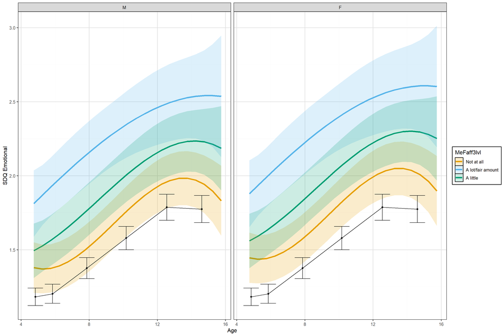

### Covariates sex, income, maternal MH

**Estimates**

[1] “No singular fit” [1] “No convergence issues”

| REML |
| --- |
| 46697.62 |

|  | Dsdem1 |  |  |  |  |  |  |  |  |  |  |
| --- | --- | --- | --- | --- | --- | --- | --- | --- | --- | --- | --- |
| Predictors | Estimates | std. Error | std. Beta | standardized std. Error | CI | standardized CI | Statistic | std. Statistic | p | std. p | df |
| (Intercept) | 1.31 | 0.07 | -0.18 | 0.04 | 1.17 – 1.45 | -0.25 – -0.10 | 18.29 | -4.76 | **<0.001** | **<0.001** | 12534.00 |
| age cent | 0.11 | 0.01 | 0.20 | 0.02 | 0.09 – 0.14 | 0.16 – 0.25 | 8.76 | 8.77 | **<0.001** | **<0.001** | 12534.00 |
| MeFaff3lvl [A lot/fair amount] | 0.45 | 0.11 | 0.23 | 0.05 | 0.24 – 0.66 | 0.13 – 0.34 | 4.27 | 4.28 | **<0.001** | **<0.001** | 12534.00 |
| MeFaff3lvl [A little] | 0.20 | 0.07 | 0.10 | 0.04 | 0.06 – 0.33 | 0.03 – 0.17 | 2.79 | 2.79 | **0.005** | **0.005** | 12534.00 |
| age cent^2 | 0.00 | 0.00 | 0.01 | 0.01 | -0.00 – 0.00 | -0.01 – 0.03 | 0.69 | 0.73 | 0.491 | 0.463 | 12534.00 |
| age cent^3 | -0.00 | 0.00 | -0.05 | 0.01 | -0.00 – -0.00 | -0.07 – -0.02 | -3.77 | -3.77 | **<0.001** | **<0.001** | 12534.00 |
| Sex [F] | 0.09 | 0.05 | 0.05 | 0.03 | -0.01 – 0.19 | -0.01 – 0.10 | 1.74 | 1.74 | 0.083 | 0.083 | 12534.00 |
| DeEqv5 [1] | 0.27 | 0.09 | 0.14 | 0.05 | 0.08 – 0.45 | 0.04 – 0.23 | 2.81 | 2.81 | **0.005** | **0.005** | 12534.00 |
| DeEqv5 [2] | 0.16 | 0.08 | 0.08 | 0.04 | -0.01 – 0.32 | -0.00 – 0.17 | 1.88 | 1.88 | 0.060 | 0.060 | 12534.00 |
| DeEqv5 [3] | 0.03 | 0.09 | 0.01 | 0.04 | -0.14 – 0.20 | -0.07 – 0.10 | 0.30 | 0.30 | 0.761 | 0.761 | 12534.00 |
| DeEqv5 [4] | -0.12 | 0.08 | -0.06 | 0.04 | -0.28 – 0.04 | -0.14 – 0.02 | -1.46 | -1.46 | 0.145 | 0.145 | 12534.00 |
| DeSf12mn | -0.30 | 0.03 | -0.15 | 0.01 | -0.35 – -0.24 | -0.18 – -0.13 | -11.18 | -11.18 | **<0.001** | **<0.001** | 12534.00 |
| age cent × MeFaff3lvl [A lot/fair amount] | -0.02 | 0.03 | -0.04 | 0.05 | -0.08 – 0.03 | -0.15 – 0.06 | -0.84 | -0.84 | 0.399 | 0.401 | 12534.00 |
| age cent × MeFaff3lvl [A little] | -0.01 | 0.02 | -0.02 | 0.04 | -0.05 – 0.03 | -0.09 – 0.06 | -0.40 | -0.39 | 0.691 | 0.694 | 12534.00 |
| MeFaff3lvl [A lot/fair amount] × age cent^2 | -0.01 | 0.00 | -0.03 | 0.02 | -0.01 – 0.00 | -0.08 – 0.01 | -1.38 | -1.39 | 0.166 | 0.163 | 12534.00 |
| MeFaff3lvl [A little] × age cent^2 | -0.00 | 0.00 | -0.02 | 0.02 | -0.01 – 0.00 | -0.06 – 0.01 | -1.26 | -1.26 | 0.209 | 0.206 | 12534.00 |
| MeFaff3lvl [A lot/fair amount] × age cent^3 | 0.00 | 0.00 | 0.04 | 0.03 | -0.00 – 0.00 | -0.02 – 0.10 | 1.40 | 1.40 | 0.162 | 0.162 | 12534.00 |
| MeFaff3lvl [A little] × age cent^3 | 0.00 | 0.00 | 0.02 | 0.02 | -0.00 – 0.00 | -0.02 – 0.07 | 1.17 | 1.17 | 0.244 | 0.244 | 12534.00 |
| Random Effects |  |  |  |  |  |  |  |  |  |  |  |
| σ<sup>2</sup> | 1.37 |  |  |  |  |  |  |  |  |  |  |
| τ<sub>00</sub> <sub>Idnumber</sub> | 1.37 |  |  |  |  |  |  |  |  |  |  |
| τ<sub>11</sub> <sub>Idnumber.age.cent</sub> | 0.03 |  |  |  |  |  |  |  |  |  |  |
| ρ<sub>01</sub> <sub>Idnumber</sub> | 0.49 |  |  |  |  |  |  |  |  |  |  |
| ICC | 0.55 |  |  |  |  |  |  |  |  |  |  |
| N <sub>Idnumber</sub> | 2118 |  |  |  |  |  |  |  |  |  |  |
| Observations | 12556 |  |  |  |  |  |  |  |  |  |  |
| Marginal R<sup>2</sup> / Conditional R<sup>2</sup> | 0.068 / 0.585 |  |  |  |  |  |  |  |  |  |  |

**Plot**

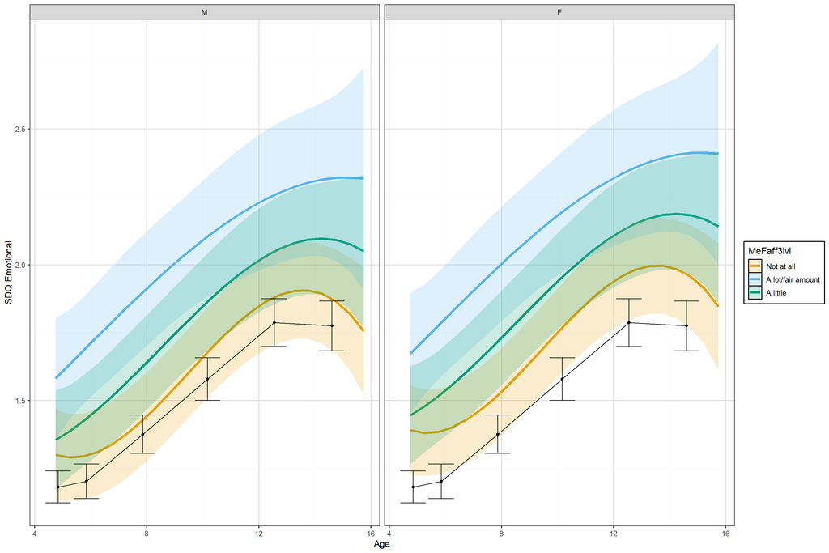

### Covariates sex, income, maternal MH, SIMD

**Estimates**

[1] “No singular fit” [1] “No convergence issues”

| REML |
| --- |
| 46707.01 |

|  | Dsdem1 |  |  |  |  |  |  |  |  |  |  |
| --- | --- | --- | --- | --- | --- | --- | --- | --- | --- | --- | --- |
| Predictors | Estimates | std. Error | std. Beta | standardized std. Error | CI | standardized CI | Statistic | std. Statistic | p | std. p | df |
| (Intercept) | 1.43 | 0.11 | -0.11 | 0.06 | 1.22 – 1.65 | -0.22 – -0.00 | 13.32 | -2.02 | **<0.001** | **0.043** | 12530.00 |
| age cent | 0.11 | 0.01 | 0.20 | 0.02 | 0.09 – 0.14 | 0.16 – 0.25 | 8.77 | 8.78 | **<0.001** | **<0.001** | 12530.00 |
| MeFaff3lvl [A lot/fair amount] | 0.44 | 0.11 | 0.23 | 0.05 | 0.24 – 0.65 | 0.12 – 0.34 | 4.18 | 4.19 | **<0.001** | **<0.001** | 12530.00 |
| MeFaff3lvl [A little] | 0.20 | 0.07 | 0.10 | 0.04 | 0.06 – 0.34 | 0.03 – 0.17 | 2.81 | 2.81 | **0.005** | **0.005** | 12530.00 |
| age cent^2 | 0.00 | 0.00 | 0.01 | 0.01 | -0.00 – 0.00 | -0.01 – 0.03 | 0.69 | 0.74 | 0.490 | 0.461 | 12530.00 |
| age cent^3 | -0.00 | 0.00 | -0.05 | 0.01 | -0.00 – -0.00 | -0.07 – -0.02 | -3.77 | -3.77 | **<0.001** | **<0.001** | 12530.00 |
| Sex [F] | 0.09 | 0.05 | 0.05 | 0.03 | -0.01 – 0.19 | -0.01 – 0.10 | 1.72 | 1.72 | 0.086 | 0.086 | 12530.00 |
| DeEqv5 [1] | 0.20 | 0.10 | 0.11 | 0.05 | 0.01 – 0.40 | 0.00 – 0.21 | 2.03 | 2.03 | **0.043** | **0.043** | 12530.00 |
| DeEqv5 [2] | 0.11 | 0.09 | 0.06 | 0.05 | -0.07 – 0.28 | -0.03 – 0.15 | 1.21 | 1.21 | 0.224 | 0.224 | 12530.00 |
| DeEqv5 [3] | -0.01 | 0.09 | -0.00 | 0.05 | -0.18 – 0.17 | -0.09 – 0.09 | -0.10 | -0.10 | 0.921 | 0.921 | 12530.00 |
| DeEqv5 [4] | -0.13 | 0.08 | -0.07 | 0.04 | -0.29 – 0.03 | -0.15 – 0.01 | -1.63 | -1.63 | 0.104 | 0.104 | 12530.00 |
| DeSf12mn | -0.30 | 0.03 | -0.15 | 0.01 | -0.35 – -0.24 | -0.18 – -0.13 | -11.10 | -11.10 | **<0.001** | **<0.001** | 12530.00 |
| ALeSNim2 [1] | -0.17 | 0.10 | -0.09 | 0.05 | -0.35 – 0.02 | -0.18 – 0.01 | -1.75 | -1.75 | 0.081 | 0.081 | 12530.00 |
| ALeSNim2 [2] | -0.09 | 0.09 | -0.05 | 0.05 | -0.27 – 0.09 | -0.14 – 0.05 | -0.99 | -0.99 | 0.323 | 0.323 | 12530.00 |
| ALeSNim2 [3] | -0.11 | 0.09 | -0.06 | 0.05 | -0.29 – 0.07 | -0.15 – 0.04 | -1.21 | -1.21 | 0.227 | 0.227 | 12530.00 |
| ALeSNim2 [4] | -0.03 | 0.10 | -0.02 | 0.05 | -0.22 – 0.16 | -0.11 – 0.08 | -0.31 | -0.31 | 0.757 | 0.757 | 12530.00 |
| age cent × MeFaff3lvl [A lot/fair amount] | -0.02 | 0.03 | -0.04 | 0.05 | -0.08 – 0.03 | -0.15 – 0.06 | -0.84 | -0.84 | 0.400 | 0.403 | 12530.00 |
| age cent × MeFaff3lvl [A little] | -0.01 | 0.02 | -0.02 | 0.04 | -0.05 – 0.03 | -0.09 – 0.06 | -0.40 | -0.39 | 0.692 | 0.695 | 12530.00 |
| MeFaff3lvl [A lot/fair amount] × age cent^2 | -0.01 | 0.00 | -0.03 | 0.02 | -0.01 – 0.00 | -0.08 – 0.01 | -1.39 | -1.40 | 0.166 | 0.163 | 12530.00 |
| MeFaff3lvl [A little] × age cent^2 | -0.00 | 0.00 | -0.02 | 0.02 | -0.01 – 0.00 | -0.06 – 0.01 | -1.26 | -1.27 | 0.208 | 0.206 | 12530.00 |
| MeFaff3lvl [A lot/fair amount] × age cent^3 | 0.00 | 0.00 | 0.04 | 0.03 | -0.00 – 0.00 | -0.02 – 0.10 | 1.40 | 1.40 | 0.162 | 0.162 | 12530.00 |
| MeFaff3lvl [A little] × age cent^3 | 0.00 | 0.00 | 0.02 | 0.02 | -0.00 – 0.00 | -0.02 – 0.07 | 1.17 | 1.17 | 0.244 | 0.244 | 12530.00 |
| Random Effects |  |  |  |  |  |  |  |  |  |  |  |
| σ<sup>2</sup> | 1.37 |  |  |  |  |  |  |  |  |  |  |
| τ<sub>00</sub> <sub>Idnumber</sub> | 1.36 |  |  |  |  |  |  |  |  |  |  |
| τ<sub>11</sub> <sub>Idnumber.age.cent</sub> | 0.03 |  |  |  |  |  |  |  |  |  |  |
| ρ<sub>01</sub> <sub>Idnumber</sub> | 0.49 |  |  |  |  |  |  |  |  |  |  |
| ICC | 0.55 |  |  |  |  |  |  |  |  |  |  |
| N <sub>Idnumber</sub> | 2118 |  |  |  |  |  |  |  |  |  |  |
| Observations | 12556 |  |  |  |  |  |  |  |  |  |  |
| Marginal R<sup>2</sup> / Conditional R<sup>2</sup> | 0.069 / 0.585 |  |  |  |  |  |  |  |  |  |  |

**Contrasts**

| Age | contrast | null.value | estimate | std.error | df | statistic | p.value |
| --- | --- | --- | --- | --- | --- | --- | --- |
| 4.844 | A little vs Not at all | 0 | 0.065 | 0.074 | 3689.047 | 0.877 | 0.381 |
| 4.844 | A lot/fair amount vs Not at all | 0 | 0.285 | 0.109 | 3101.783 | 2.602 | 0.009 |
| 4.844 | A lot/fair amount vs A little | 0 | 0.220 | 0.115 | 3114.123 | 1.918 | 0.055 |
| 7.863 | A little vs Not at all | 0 | 0.199 | 0.070 | 3990.625 | 2.850 | 0.004 |
| 7.863 | A lot/fair amount vs Not at all | 0 | 0.462 | 0.104 | 3396.652 | 4.421 | 0.000 |
| 7.863 | A lot/fair amount vs A little | 0 | 0.263 | 0.109 | 3475.826 | 2.408 | 0.016 |
| 14.609 | A little vs Not at all | 0 | 0.221 | 0.105 | 2815.170 | 2.102 | 0.036 |
| 14.609 | A lot/fair amount vs Not at all | 0 | 0.435 | 0.156 | 2621.305 | 2.788 | 0.005 |
| 14.609 | A lot/fair amount vs A little | 0 | 0.215 | 0.165 | 2568.909 | 1.303 | 0.193 |

**Plot: Lowest level covariates**

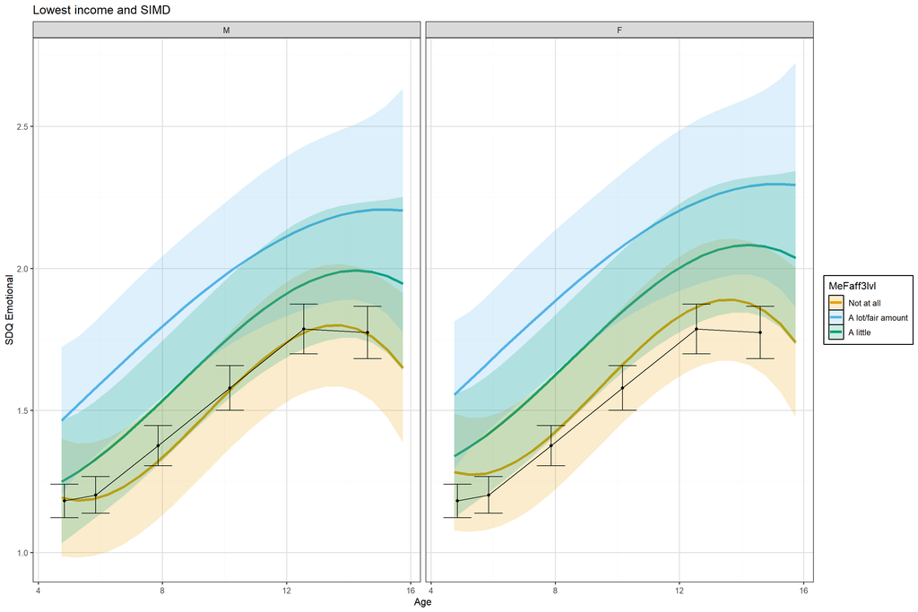

**Plot: Highest level covariates**

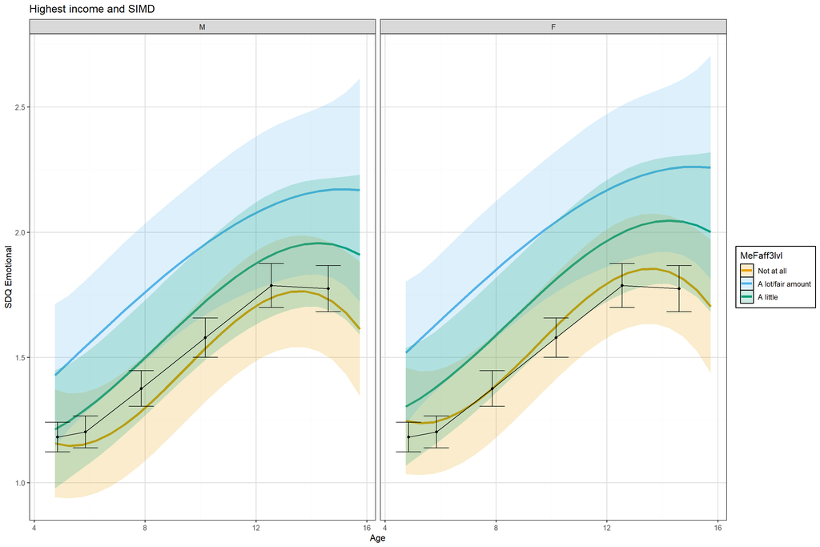

## Hyperactivity and FI

### No covariates

**Estimates**

[1] “No singular fit” [1] “No convergence issues”

| REML |
| --- |
| 50413.77 |

|  | Dsdhy1 |  |  |  |  |  |  |  |  |  |  |
| --- | --- | --- | --- | --- | --- | --- | --- | --- | --- | --- | --- |
| Predictors | Estimates | std. Error | std. Beta | standardized std. Error | CI | standardized CI | Statistic | std. Statistic | p | std. p | df |
| (Intercept) | 2.87 | 0.06 | -0.18 | 0.02 | 2.76 – 2.97 | -0.23 – -0.14 | 51.47 | -8.22 | **<0.001** | **<0.001** | 12581.00 |
| age cent | -0.09 | 0.01 | -0.12 | 0.01 | -0.10 – -0.07 | -0.14 – -0.10 | -12.59 | -12.59 | **<0.001** | **<0.001** | 12581.00 |
| MeFaff3lvl [A lot/fair amount] | 0.99 | 0.14 | 0.40 | 0.06 | 0.71 – 1.27 | 0.29 – 0.51 | 7.01 | 7.01 | **<0.001** | **<0.001** | 12581.00 |
| MeFaff3lvl [A little] | 0.30 | 0.09 | 0.12 | 0.04 | 0.12 – 0.49 | 0.05 – 0.20 | 3.21 | 3.21 | **0.001** | **0.001** | 12581.00 |
| age cent × MeFaff3lvl [A lot/fair amount] | -0.01 | 0.02 | -0.01 | 0.02 | -0.04 – 0.03 | -0.06 – 0.04 | -0.42 | -0.42 | 0.673 | 0.673 | 12581.00 |
| age cent × MeFaff3lvl [A little] | -0.01 | 0.01 | -0.01 | 0.02 | -0.03 – 0.01 | -0.05 – 0.02 | -0.88 | -0.88 | 0.378 | 0.378 | 12581.00 |
| Random Effects |  |  |  |  |  |  |  |  |  |  |  |
| σ<sup>2</sup> | 1.60 |  |  |  |  |  |  |  |  |  |  |
| τ<sub>00</sub> <sub>Idnumber</sub> | 3.51 |  |  |  |  |  |  |  |  |  |  |
| τ<sub>11</sub> <sub>Idnumber.age.cent</sub> | 0.03 |  |  |  |  |  |  |  |  |  |  |
| ρ<sub>01</sub> <sub>Idnumber</sub> | 0.05 |  |  |  |  |  |  |  |  |  |  |
| ICC | 0.71 |  |  |  |  |  |  |  |  |  |  |
| N <sub>Idnumber</sub> | 2125 |  |  |  |  |  |  |  |  |  |  |
| Observations | 12591 |  |  |  |  |  |  |  |  |  |  |
| Marginal R<sup>2</sup> / Conditional R<sup>2</sup> | 0.034 / 0.720 |  |  |  |  |  |  |  |  |  |  |

**Contrasts**

| Age | contrast | null.value | estimate | std.error | df | statistic | p.value |
| --- | --- | --- | --- | --- | --- | --- | --- |
| 4.844 | A little vs Not at all | 0 | 0.349 | 0.106 | 2161.681 | 3.284 | 0.001 |
| 4.844 | A lot/fair amount vs Not at all | 0 | 1.022 | 0.158 | 2049.021 | 6.480 | 0.000 |
| 4.844 | A lot/fair amount vs A little | 0 | 0.674 | 0.168 | 2053.596 | 4.005 | 0.000 |
| 7.863 | A little vs Not at all | 0 | 0.317 | 0.095 | 2142.911 | 3.332 | 0.001 |
| 7.863 | A lot/fair amount vs Not at all | 0 | 1.000 | 0.142 | 2082.331 | 7.022 | 0.000 |
| 7.863 | A lot/fair amount vs A little | 0 | 0.683 | 0.152 | 2085.069 | 4.498 | 0.000 |
| 14.609 | A little vs Not at all | 0 | 0.248 | 0.115 | 2193.190 | 2.155 | 0.031 |
| 14.609 | A lot/fair amount vs Not at all | 0 | 0.952 | 0.171 | 2074.658 | 5.573 | 0.000 |
| 14.609 | A lot/fair amount vs A little | 0 | 0.704 | 0.182 | 2076.790 | 3.868 | 0.000 |

**Plot**

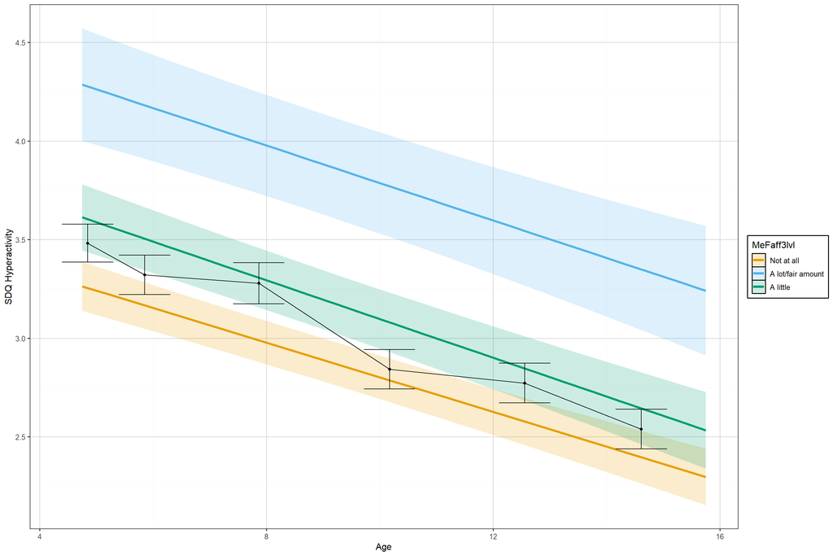

### Covariates sex and income

**Estimates**

[1] “No singular fit” [1] “No convergence issues”

| REML |
| --- |
| 50273.18 |

|  | Dsdhy1 |  |  |  |  |  |  |  |  |  |  |
| --- | --- | --- | --- | --- | --- | --- | --- | --- | --- | --- | --- |
| Predictors | Estimates | std. Error | std. Beta | standardized std. Error | CI | standardized CI | Statistic | std. Statistic | p | std. p | df |
| (Intercept) | 2.96 | 0.10 | -0.14 | 0.04 | 2.76 – 3.17 | -0.23 – -0.06 | 28.28 | -3.44 | **<0.001** | **0.001** | 12576.00 |
| age cent | -0.09 | 0.01 | -0.12 | 0.01 | -0.10 – -0.07 | -0.14 – -0.10 | -12.55 | -12.55 | **<0.001** | **<0.001** | 12576.00 |
| MeFaff3lvl [A lot/fair amount] | 0.64 | 0.14 | 0.26 | 0.06 | 0.36 – 0.92 | 0.14 – 0.37 | 4.50 | 4.50 | **<0.001** | **<0.001** | 12576.00 |
| MeFaff3lvl [A little] | 0.19 | 0.09 | 0.08 | 0.04 | 0.01 – 0.37 | 0.01 – 0.15 | 2.10 | 2.10 | **0.036** | **0.036** | 12576.00 |
| Sex [F] | -0.79 | 0.08 | -0.32 | 0.03 | -0.95 – -0.63 | -0.38 – -0.25 | -9.63 | -9.63 | **<0.001** | **<0.001** | 12576.00 |
| DeEqv5 [1] | 1.07 | 0.15 | 0.43 | 0.06 | 0.78 – 1.35 | 0.31 – 0.54 | 7.20 | 7.20 | **<0.001** | **<0.001** | 12576.00 |
| DeEqv5 [2] | 0.57 | 0.13 | 0.23 | 0.05 | 0.32 – 0.83 | 0.13 – 0.33 | 4.38 | 4.38 | **<0.001** | **<0.001** | 12576.00 |
| DeEqv5 [3] | 0.33 | 0.13 | 0.13 | 0.05 | 0.07 – 0.59 | 0.03 – 0.24 | 2.45 | 2.45 | **0.014** | **0.014** | 12576.00 |
| DeEqv5 [4] | 0.08 | 0.12 | 0.03 | 0.05 | -0.16 – 0.32 | -0.07 – 0.13 | 0.64 | 0.64 | 0.524 | 0.524 | 12576.00 |
| age cent × MeFaff3lvl [A lot/fair amount] | -0.01 | 0.02 | -0.01 | 0.02 | -0.04 – 0.03 | -0.06 – 0.04 | -0.41 | -0.41 | 0.679 | 0.679 | 12576.00 |
| age cent × MeFaff3lvl [A little] | -0.01 | 0.01 | -0.01 | 0.02 | -0.03 – 0.01 | -0.05 – 0.02 | -0.88 | -0.88 | 0.377 | 0.377 | 12576.00 |
| Random Effects |  |  |  |  |  |  |  |  |  |  |  |
| σ<sup>2</sup> | 1.60 |  |  |  |  |  |  |  |  |  |  |
| τ<sub>00</sub> <sub>Idnumber</sub> | 3.25 |  |  |  |  |  |  |  |  |  |  |
| τ<sub>11</sub> <sub>Idnumber.age.cent</sub> | 0.03 |  |  |  |  |  |  |  |  |  |  |
| ρ<sub>01</sub> <sub>Idnumber</sub> | 0.02 |  |  |  |  |  |  |  |  |  |  |
| ICC | 0.70 |  |  |  |  |  |  |  |  |  |  |
| N <sub>Idnumber</sub> | 2125 |  |  |  |  |  |  |  |  |  |  |
| Observations | 12591 |  |  |  |  |  |  |  |  |  |  |
| Marginal R<sup>2</sup> / Conditional R<sup>2</sup> | 0.081 / 0.720 |  |  |  |  |  |  |  |  |  |  |

**Plot**

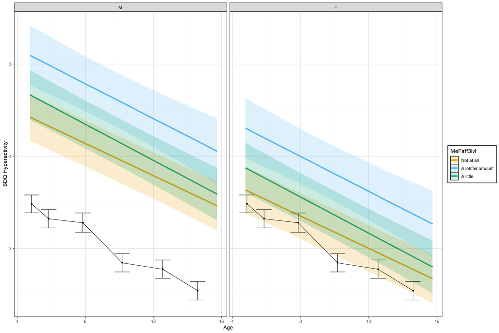

### Covariates sex, income, maternal MH

**Estimates**

[1] “No singular fit” [1] “No convergence issues”

| REML |
| --- |
| 50062.85 |

|  | Dsdhy1 |  |  |  |  |  |  |  |  |  |  |
| --- | --- | --- | --- | --- | --- | --- | --- | --- | --- | --- | --- |
| Predictors | Estimates | std. Error | std. Beta | standardized std. Error | CI | standardized CI | Statistic | std. Statistic | p | std. p | df |
| (Intercept) | 3.05 | 0.10 | -0.11 | 0.04 | 2.85 – 3.26 | -0.19 – -0.02 | 29.54 | -2.54 | **<0.001** | **0.011** | 12540.00 |
| age cent | -0.09 | 0.01 | -0.12 | 0.01 | -0.10 – -0.07 | -0.14 – -0.10 | -12.55 | -12.55 | **<0.001** | **<0.001** | 12540.00 |
| MeFaff3lvl [A lot/fair amount] | 0.46 | 0.14 | 0.19 | 0.06 | 0.18 – 0.74 | 0.07 – 0.30 | 3.25 | 3.25 | **0.001** | **0.001** | 12540.00 |
| MeFaff3lvl [A little] | 0.12 | 0.09 | 0.05 | 0.04 | -0.06 – 0.29 | -0.03 – 0.12 | 1.27 | 1.27 | 0.204 | 0.203 | 12540.00 |
| Sex [F] | -0.77 | 0.08 | -0.31 | 0.03 | -0.93 – -0.61 | -0.37 – -0.25 | -9.50 | -9.50 | **<0.001** | **<0.001** | 12540.00 |
| DeEqv5 [1] | 0.88 | 0.15 | 0.36 | 0.06 | 0.60 – 1.17 | 0.24 – 0.47 | 6.03 | 6.03 | **<0.001** | **<0.001** | 12540.00 |
| DeEqv5 [2] | 0.48 | 0.13 | 0.19 | 0.05 | 0.23 – 0.73 | 0.09 – 0.30 | 3.71 | 3.71 | **<0.001** | **<0.001** | 12540.00 |
| DeEqv5 [3] | 0.29 | 0.13 | 0.12 | 0.05 | 0.03 – 0.55 | 0.01 – 0.22 | 2.17 | 2.17 | **0.030** | **0.030** | 12540.00 |
| DeEqv5 [4] | 0.05 | 0.12 | 0.02 | 0.05 | -0.19 – 0.29 | -0.08 – 0.12 | 0.42 | 0.42 | 0.678 | 0.678 | 12540.00 |
| DeSf12mn | -0.36 | 0.04 | -0.14 | 0.02 | -0.44 – -0.28 | -0.18 – -0.11 | -8.63 | -8.63 | **<0.001** | **<0.001** | 12540.00 |
| age cent × MeFaff3lvl [A lot/fair amount] | -0.01 | 0.02 | -0.01 | 0.02 | -0.04 – 0.03 | -0.06 – 0.04 | -0.33 | -0.33 | 0.738 | 0.738 | 12540.00 |
| age cent × MeFaff3lvl [A little] | -0.01 | 0.01 | -0.01 | 0.02 | -0.03 – 0.01 | -0.05 – 0.02 | -0.89 | -0.89 | 0.375 | 0.375 | 12540.00 |
| Random Effects |  |  |  |  |  |  |  |  |  |  |  |
| σ<sup>2</sup> | 1.60 |  |  |  |  |  |  |  |  |  |  |
| τ<sub>00</sub> <sub>Idnumber</sub> | 3.12 |  |  |  |  |  |  |  |  |  |  |
| τ<sub>11</sub> <sub>Idnumber.age.cent</sub> | 0.03 |  |  |  |  |  |  |  |  |  |  |
| ρ<sub>01</sub> <sub>Idnumber</sub> | 0.03 |  |  |  |  |  |  |  |  |  |  |
| ICC | 0.69 |  |  |  |  |  |  |  |  |  |  |
| N <sub>Idnumber</sub> | 2118 |  |  |  |  |  |  |  |  |  |  |
| Observations | 12556 |  |  |  |  |  |  |  |  |  |  |
| Marginal R<sup>2</sup> / Conditional R<sup>2</sup> | 0.101 / 0.719 |  |  |  |  |  |  |  |  |  |  |

**Plot**

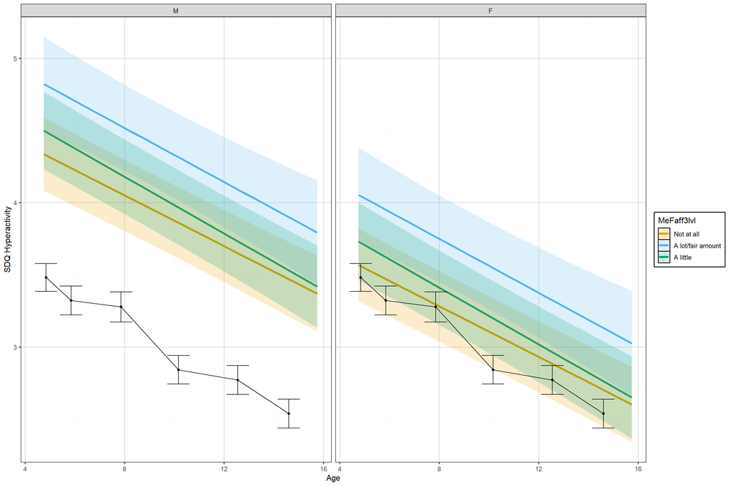

### Covariates sex, income, maternal MH, SIMD

**Estimates**

[1] “No singular fit” [1] “No convergence issues”

| REML |
| --- |
| 50058.47 |

|  | Dsdhy1 |  |  |  |  |  |  |  |  |  |  |
| --- | --- | --- | --- | --- | --- | --- | --- | --- | --- | --- | --- |
| Predictors | Estimates | std. Error | std. Beta | standardized std. Error | CI | standardized CI | Statistic | std. Statistic | p | std. p | df |
| (Intercept) | 3.48 | 0.16 | 0.06 | 0.07 | 3.16 – 3.80 | -0.06 – 0.19 | 21.36 | 0.98 | **<0.001** | 0.328 | 12536.00 |
| age cent | -0.09 | 0.01 | -0.12 | 0.01 | -0.10 – -0.07 | -0.14 – -0.10 | -12.55 | -12.55 | **<0.001** | **<0.001** | 12536.00 |
| MeFaff3lvl [A lot/fair amount] | 0.45 | 0.14 | 0.18 | 0.06 | 0.17 – 0.72 | 0.07 – 0.29 | 3.15 | 3.15 | **0.002** | **0.002** | 12536.00 |
| MeFaff3lvl [A little] | 0.12 | 0.09 | 0.05 | 0.04 | -0.06 – 0.30 | -0.02 – 0.12 | 1.34 | 1.34 | 0.180 | 0.179 | 12536.00 |
| Sex [F] | -0.77 | 0.08 | -0.31 | 0.03 | -0.93 – -0.62 | -0.38 – -0.25 | -9.60 | -9.60 | **<0.001** | **<0.001** | 12536.00 |
| DeEqv5 [1] | 0.71 | 0.15 | 0.28 | 0.06 | 0.40 – 1.01 | 0.16 – 0.41 | 4.55 | 4.55 | **<0.001** | **<0.001** | 12536.00 |
| DeEqv5 [2] | 0.35 | 0.14 | 0.14 | 0.05 | 0.08 – 0.62 | 0.03 – 0.25 | 2.58 | 2.58 | **0.010** | **0.010** | 12536.00 |
| DeEqv5 [3] | 0.20 | 0.14 | 0.08 | 0.05 | -0.06 – 0.47 | -0.03 – 0.19 | 1.50 | 1.50 | 0.133 | 0.133 | 12536.00 |
| DeEqv5 [4] | 0.02 | 0.12 | 0.01 | 0.05 | -0.22 – 0.26 | -0.09 – 0.10 | 0.15 | 0.15 | 0.880 | 0.880 | 12536.00 |
| DeSf12mn | -0.35 | 0.04 | -0.14 | 0.02 | -0.43 – -0.27 | -0.17 – -0.11 | -8.41 | -8.41 | **<0.001** | **<0.001** | 12536.00 |
| ALeSNim2 [1] | -0.48 | 0.15 | -0.19 | 0.06 | -0.77 – -0.19 | -0.31 – -0.07 | -3.21 | -3.21 | **0.001** | **0.001** | 12536.00 |
| ALeSNim2 [2] | -0.48 | 0.14 | -0.19 | 0.06 | -0.76 – -0.20 | -0.31 – -0.08 | -3.32 | -3.32 | **0.001** | **0.001** | 12536.00 |
| ALeSNim2 [3] | -0.35 | 0.14 | -0.14 | 0.06 | -0.63 – -0.06 | -0.25 – -0.03 | -2.39 | -2.39 | **0.017** | **0.017** | 12536.00 |
| ALeSNim2 [4] | -0.20 | 0.15 | -0.08 | 0.06 | -0.50 – 0.09 | -0.20 – 0.04 | -1.37 | -1.37 | 0.171 | 0.171 | 12536.00 |
| age cent × MeFaff3lvl [A lot/fair amount] | -0.01 | 0.02 | -0.01 | 0.02 | -0.04 – 0.03 | -0.06 – 0.04 | -0.34 | -0.34 | 0.737 | 0.737 | 12536.00 |
| age cent × MeFaff3lvl [A little] | -0.01 | 0.01 | -0.01 | 0.02 | -0.03 – 0.01 | -0.05 – 0.02 | -0.89 | -0.89 | 0.374 | 0.374 | 12536.00 |
| Random Effects |  |  |  |  |  |  |  |  |  |  |  |
| σ<sup>2</sup> | 1.60 |  |  |  |  |  |  |  |  |  |  |
| τ<sub>00</sub> <sub>Idnumber</sub> | 3.10 |  |  |  |  |  |  |  |  |  |  |
| τ<sub>11</sub> <sub>Idnumber.age.cent</sub> | 0.03 |  |  |  |  |  |  |  |  |  |  |
| ρ<sub>01</sub> <sub>Idnumber</sub> | 0.04 |  |  |  |  |  |  |  |  |  |  |
| ICC | 0.69 |  |  |  |  |  |  |  |  |  |  |
| N <sub>Idnumber</sub> | 2118 |  |  |  |  |  |  |  |  |  |  |
| Observations | 12556 |  |  |  |  |  |  |  |  |  |  |
| Marginal R<sup>2</sup> / Conditional R<sup>2</sup> | 0.104 / 0.720 |  |  |  |  |  |  |  |  |  |  |

**Contrasts**

| Age | contrast | null.value | estimate | std.error | df | statistic | p.value |
| --- | --- | --- | --- | --- | --- | --- | --- |
| 4.844 | A little vs Not at all | 0 | 0.168 | 0.103 | 2165.972 | 1.625 | 0.104 |
| 4.844 | A lot/fair amount vs Not at all | 0 | 0.471 | 0.159 | 2103.754 | 2.972 | 0.003 |
| 4.844 | A lot/fair amount vs A little | 0 | 0.303 | 0.165 | 2067.496 | 1.832 | 0.067 |
| 7.863 | A little vs Not at all | 0 | 0.137 | 0.092 | 2130.243 | 1.487 | 0.137 |
| 7.863 | A lot/fair amount vs Not at all | 0 | 0.454 | 0.143 | 2075.731 | 3.180 | 0.001 |
| 7.863 | A lot/fair amount vs A little | 0 | 0.317 | 0.148 | 2070.306 | 2.142 | 0.032 |
| 14.609 | A little vs Not at all | 0 | 0.066 | 0.112 | 2211.401 | 0.593 | 0.553 |
| 14.609 | A lot/fair amount vs Not at all | 0 | 0.415 | 0.170 | 2157.120 | 2.434 | 0.015 |
| 14.609 | A lot/fair amount vs A little | 0 | 0.349 | 0.178 | 2106.207 | 1.956 | 0.051 |

**Plot: Lowest level covariates**

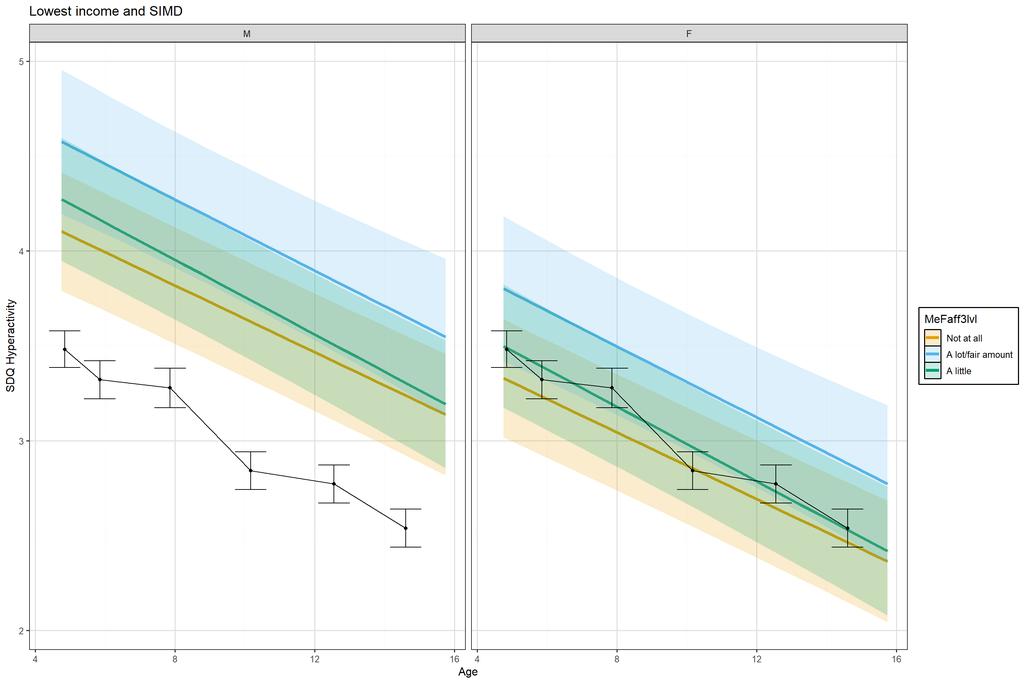

**Plot: Highest level covariates**

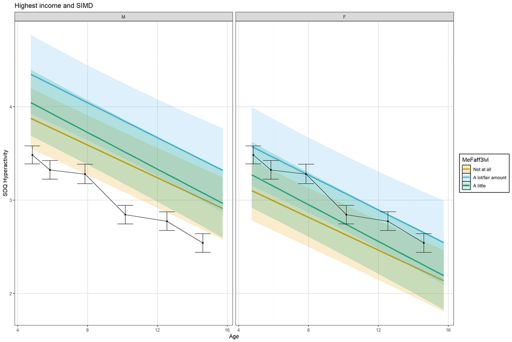

## Peer problems and FI

### No covariates

**Estimates**

[1] “No singular fit” [1] “No convergence issues”

| REML |
| --- |
| 43027.02 |

|  | Dsdpr1 |  |  |  |  |  |  |  |  |  |  |
| --- | --- | --- | --- | --- | --- | --- | --- | --- | --- | --- | --- |
| Predictors | Estimates | std. Error | std. Beta | standardized std. Error | CI | standardized CI | Statistic | std. Statistic | p | std. p | df |
| (Intercept) | 0.98 | 0.04 | -0.18 | 0.02 | 0.90 – 1.05 | -0.22 – -0.13 | 24.55 | -7.38 | **<0.001** | **<0.001** | 12572.00 |
| age cent | 0.08 | 0.01 | 0.16 | 0.03 | 0.05 – 0.10 | 0.11 – 0.21 | 6.43 | 6.41 | **<0.001** | **<0.001** | 12572.00 |
| MeFaff3lvl [A lot/fair amount] | 0.72 | 0.10 | 0.43 | 0.06 | 0.53 – 0.91 | 0.32 – 0.54 | 7.38 | 7.38 | **<0.001** | **<0.001** | 12572.00 |
| MeFaff3lvl [A little] | 0.25 | 0.07 | 0.15 | 0.04 | 0.12 – 0.38 | 0.07 – 0.23 | 3.68 | 3.68 | **<0.001** | **<0.001** | 12572.00 |
| age cent^2 | -0.00 | 0.00 | -0.00 | 0.04 | -0.01 – 0.01 | -0.07 – 0.07 | -0.08 | -0.08 | 0.933 | 0.939 | 12572.00 |
| age cent^3 | -0.00 | 0.00 | -0.04 | 0.02 | -0.00 – -0.00 | -0.07 – -0.00 | -2.20 | -2.20 | **0.028** | **0.028** | 12572.00 |
| age cent^4 | 0.00 | 0.00 | 0.02 | 0.02 | -0.00 – 0.00 | -0.02 – 0.05 | 0.91 | 0.91 | 0.363 | 0.363 | 12572.00 |
| age cent × MeFaff3lvl [A lot/fair amount] | 0.03 | 0.03 | 0.07 | 0.06 | -0.02 – 0.09 | -0.05 – 0.18 | 1.14 | 1.15 | 0.256 | 0.250 | 12572.00 |
| age cent × MeFaff3lvl [A little] | 0.01 | 0.02 | 0.03 | 0.04 | -0.02 – 0.05 | -0.05 – 0.11 | 0.72 | 0.72 | 0.474 | 0.469 | 12572.00 |
| MeFaff3lvl [A lot/fair amount] × age cent^2 | -0.02 | 0.01 | -0.17 | 0.08 | -0.05 – -0.00 | -0.33 – -0.01 | -2.10 | -2.11 | **0.035** | **0.035** | 12572.00 |
| MeFaff3lvl [A little] × age cent^2 | -0.01 | 0.01 | -0.07 | 0.06 | -0.03 – 0.01 | -0.19 – 0.04 | -1.23 | -1.23 | 0.220 | 0.219 | 12572.00 |
| MeFaff3lvl [A lot/fair amount] × age cent^3 | -0.00 | 0.00 | -0.03 | 0.04 | -0.00 – 0.00 | -0.10 – 0.05 | -0.73 | -0.75 | 0.464 | 0.454 | 12572.00 |
| MeFaff3lvl [A little] × age cent^3 | 0.00 | 0.00 | 0.00 | 0.03 | -0.00 – 0.00 | -0.05 – 0.06 | 0.08 | 0.07 | 0.935 | 0.945 | 12572.00 |
| MeFaff3lvl [A lot/fair amount] × age cent^4 | 0.00 | 0.00 | 0.07 | 0.04 | -0.00 – 0.00 | -0.00 – 0.15 | 1.83 | 1.83 | 0.067 | 0.067 | 12572.00 |
| MeFaff3lvl [A little] × age cent^4 | 0.00 | 0.00 | 0.03 | 0.03 | -0.00 – 0.00 | -0.02 – 0.09 | 1.14 | 1.14 | 0.256 | 0.256 | 12572.00 |
| Random Effects |  |  |  |  |  |  |  |  |  |  |  |
| σ<sup>2</sup> | 1.00 |  |  |  |  |  |  |  |  |  |  |
| τ<sub>00</sub> <sub>Idnumber</sub> | 1.17 |  |  |  |  |  |  |  |  |  |  |
| τ<sub>11</sub> <sub>Idnumber.age.cent</sub> | 0.02 |  |  |  |  |  |  |  |  |  |  |
| ρ<sub>01</sub> <sub>Idnumber</sub> | 0.51 |  |  |  |  |  |  |  |  |  |  |
| ICC | 0.59 |  |  |  |  |  |  |  |  |  |  |
| N <sub>Idnumber</sub> | 2125 |  |  |  |  |  |  |  |  |  |  |
| Observations | 12591 |  |  |  |  |  |  |  |  |  |  |
| Marginal R<sup>2</sup> / Conditional R<sup>2</sup> | 0.036 / 0.600 |  |  |  |  |  |  |  |  |  |  |

**Contrasts**

| Age | contrast | null.value | estimate | std.error | df | statistic | p.value |
| --- | --- | --- | --- | --- | --- | --- | --- |
| 4.844 | A little vs Not at all | 0 | 0.118 | 0.066 | 4076.812 | 1.785 | 0.074 |
| 4.844 | A lot/fair amount vs Not at all | 0 | 0.519 | 0.095 | 3423.095 | 5.469 | 0.000 |
| 4.844 | A lot/fair amount vs A little | 0 | 0.401 | 0.101 | 3445.372 | 3.956 | 0.000 |
| 7.863 | A little vs Not at all | 0 | 0.207 | 0.062 | 3858.966 | 3.358 | 0.001 |
| 7.863 | A lot/fair amount vs Not at all | 0 | 0.634 | 0.090 | 3393.442 | 7.059 | 0.000 |
| 7.863 | A lot/fair amount vs A little | 0 | 0.426 | 0.096 | 3408.297 | 4.451 | 0.000 |
| 14.609 | A little vs Not at all | 0 | 0.345 | 0.092 | 2800.310 | 3.759 | 0.000 |
| 14.609 | A lot/fair amount vs Not at all | 0 | 0.699 | 0.135 | 2539.935 | 5.194 | 0.000 |
| 14.609 | A lot/fair amount vs A little | 0 | 0.354 | 0.143 | 2545.266 | 2.470 | 0.014 |

**Plot**

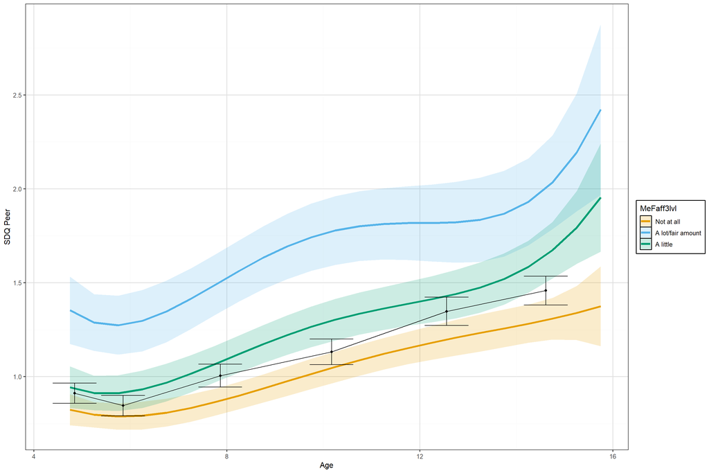

### Covariates sex and income

**Estimates**

[1] “No singular fit” [1] “No convergence issues”

| REML |
| --- |
| 42953.91 |

|  | Dsdpr1 |  |  |  |  |  |  |  |  |  |  |
| --- | --- | --- | --- | --- | --- | --- | --- | --- | --- | --- | --- |
| Predictors | Estimates | std. Error | std. Beta | standardized std. Error | CI | standardized CI | Statistic | std. Statistic | p | std. p | df |
| (Intercept) | 0.88 | 0.06 | -0.23 | 0.04 | 0.75 – 1.01 | -0.31 – -0.16 | 13.56 | -6.01 | **<0.001** | **<0.001** | 12567.00 |
| age cent | 0.08 | 0.01 | 0.17 | 0.03 | 0.06 – 0.10 | 0.12 – 0.22 | 6.52 | 6.51 | **<0.001** | **<0.001** | 12567.00 |
| MeFaff3lvl [A lot/fair amount] | 0.52 | 0.10 | 0.31 | 0.06 | 0.33 – 0.71 | 0.20 – 0.43 | 5.27 | 5.27 | **<0.001** | **<0.001** | 12567.00 |
| MeFaff3lvl [A little] | 0.18 | 0.07 | 0.11 | 0.04 | 0.05 – 0.31 | 0.03 – 0.19 | 2.76 | 2.76 | **0.006** | **0.006** | 12567.00 |
| age cent^2 | -0.00 | 0.00 | -0.00 | 0.04 | -0.01 – 0.01 | -0.07 – 0.07 | -0.09 | -0.08 | 0.926 | 0.933 | 12567.00 |
| age cent^3 | -0.00 | 0.00 | -0.04 | 0.02 | -0.00 – -0.00 | -0.07 – -0.00 | -2.21 | -2.20 | **0.027** | **0.028** | 12567.00 |
| age cent^4 | 0.00 | 0.00 | 0.02 | 0.02 | -0.00 – 0.00 | -0.02 – 0.05 | 0.92 | 0.92 | 0.358 | 0.358 | 12567.00 |
| Sex [F] | -0.20 | 0.05 | -0.12 | 0.03 | -0.29 – -0.11 | -0.18 – -0.07 | -4.32 | -4.32 | **<0.001** | **<0.001** | 12567.00 |
| DeEqv5 [1] | 0.62 | 0.08 | 0.37 | 0.05 | 0.46 – 0.79 | 0.28 – 0.47 | 7.49 | 7.49 | **<0.001** | **<0.001** | 12567.00 |
| DeEqv5 [2] | 0.35 | 0.07 | 0.21 | 0.04 | 0.20 – 0.49 | 0.12 – 0.30 | 4.64 | 4.64 | **<0.001** | **<0.001** | 12567.00 |
| DeEqv5 [3] | 0.29 | 0.08 | 0.17 | 0.05 | 0.14 – 0.44 | 0.08 – 0.26 | 3.71 | 3.71 | **<0.001** | **<0.001** | 12567.00 |
| DeEqv5 [4] | 0.05 | 0.07 | 0.03 | 0.04 | -0.09 – 0.19 | -0.05 – 0.11 | 0.71 | 0.71 | 0.478 | 0.478 | 12567.00 |
| age cent × MeFaff3lvl [A lot/fair amount] | 0.03 | 0.03 | 0.07 | 0.06 | -0.02 – 0.09 | -0.05 – 0.18 | 1.15 | 1.16 | 0.250 | 0.245 | 12567.00 |
| age cent × MeFaff3lvl [A little] | 0.01 | 0.02 | 0.03 | 0.04 | -0.02 – 0.05 | -0.05 – 0.11 | 0.72 | 0.73 | 0.471 | 0.466 | 12567.00 |
| MeFaff3lvl [A lot/fair amount] × age cent^2 | -0.02 | 0.01 | -0.17 | 0.08 | -0.05 – -0.00 | -0.33 – -0.01 | -2.11 | -2.11 | **0.035** | **0.035** | 12567.00 |
| MeFaff3lvl [A little] × age cent^2 | -0.01 | 0.01 | -0.07 | 0.06 | -0.03 – 0.01 | -0.19 – 0.04 | -1.22 | -1.22 | 0.223 | 0.222 | 12567.00 |
| MeFaff3lvl [A lot/fair amount] × age cent^3 | -0.00 | 0.00 | -0.03 | 0.04 | -0.00 – 0.00 | -0.10 – 0.05 | -0.74 | -0.75 | 0.461 | 0.452 | 12567.00 |
| MeFaff3lvl [A little] × age cent^3 | 0.00 | 0.00 | 0.00 | 0.03 | -0.00 – 0.00 | -0.05 – 0.06 | 0.09 | 0.07 | 0.932 | 0.942 | 12567.00 |
| MeFaff3lvl [A lot/fair amount] × age cent^4 | 0.00 | 0.00 | 0.07 | 0.04 | -0.00 – 0.00 | -0.00 – 0.15 | 1.84 | 1.84 | 0.067 | 0.067 | 12567.00 |
| MeFaff3lvl [A little] × age cent^4 | 0.00 | 0.00 | 0.03 | 0.03 | -0.00 – 0.00 | -0.02 – 0.09 | 1.13 | 1.13 | 0.259 | 0.259 | 12567.00 |
| Random Effects |  |  |  |  |  |  |  |  |  |  |  |
| σ<sup>2</sup> | 1.00 |  |  |  |  |  |  |  |  |  |  |
| τ<sub>00</sub> <sub>Idnumber</sub> | 1.11 |  |  |  |  |  |  |  |  |  |  |
| τ<sub>11</sub> <sub>Idnumber.age.cent</sub> | 0.02 |  |  |  |  |  |  |  |  |  |  |
| ρ<sub>01</sub> <sub>Idnumber</sub> | 0.50 |  |  |  |  |  |  |  |  |  |  |
| ICC | 0.57 |  |  |  |  |  |  |  |  |  |  |
| N <sub>Idnumber</sub> | 2125 |  |  |  |  |  |  |  |  |  |  |
| Observations | 12591 |  |  |  |  |  |  |  |  |  |  |
| Marginal R<sup>2</sup> / Conditional R<sup>2</sup> | 0.057 / 0.598 |  |  |  |  |  |  |  |  |  |  |

**Plot**

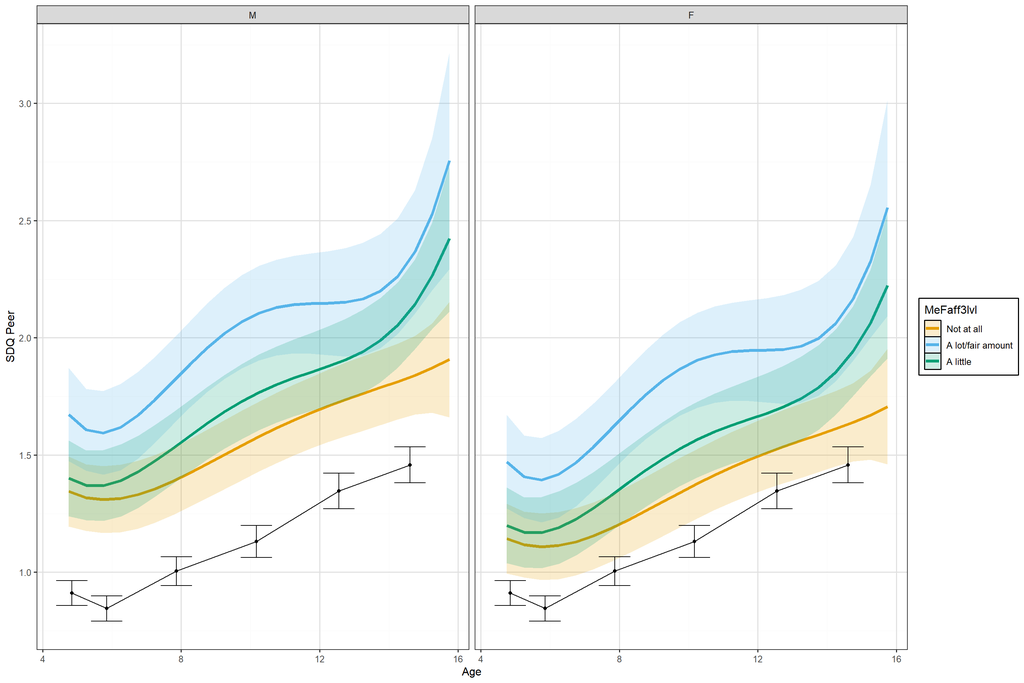

### Covariates sex, income, maternal MH

**Estimates**

[1] “No singular fit” [1] “No convergence issues”

| REML |
| --- |
| 42729.31 |

|  | Dsdpr1 |  |  |  |  |  |  |  |  |  |  |
| --- | --- | --- | --- | --- | --- | --- | --- | --- | --- | --- | --- |
| Predictors | Estimates | std. Error | std. Beta | standardized std. Error | CI | standardized CI | Statistic | std. Statistic | p | std. p | df |
| (Intercept) | 0.93 | 0.06 | -0.20 | 0.04 | 0.80 – 1.05 | -0.28 – -0.13 | 14.49 | -5.22 | **<0.001** | **<0.001** | 12531.00 |
| age cent | 0.08 | 0.01 | 0.17 | 0.03 | 0.06 – 0.10 | 0.12 – 0.22 | 6.65 | 6.63 | **<0.001** | **<0.001** | 12531.00 |
| MeFaff3lvl [A lot/fair amount] | 0.42 | 0.10 | 0.26 | 0.06 | 0.23 – 0.62 | 0.14 – 0.37 | 4.32 | 4.32 | **<0.001** | **<0.001** | 12531.00 |
| MeFaff3lvl [A little] | 0.14 | 0.07 | 0.08 | 0.04 | 0.01 – 0.27 | 0.01 – 0.16 | 2.10 | 2.10 | **0.035** | **0.035** | 12531.00 |
| age cent^2 | -0.00 | 0.00 | -0.01 | 0.04 | -0.01 – 0.01 | -0.08 – 0.06 | -0.18 | -0.17 | 0.853 | 0.863 | 12531.00 |
| age cent^3 | -0.00 | 0.00 | -0.04 | 0.02 | -0.00 – -0.00 | -0.07 – -0.01 | -2.33 | -2.32 | **0.020** | **0.020** | 12531.00 |
| age cent^4 | 0.00 | 0.00 | 0.02 | 0.02 | -0.00 – 0.00 | -0.02 – 0.05 | 1.02 | 1.02 | 0.310 | 0.310 | 12531.00 |
| Sex [F] | -0.18 | 0.05 | -0.11 | 0.03 | -0.27 – -0.09 | -0.16 – -0.06 | -4.00 | -4.00 | **<0.001** | **<0.001** | 12531.00 |
| DeEqv5 [1] | 0.52 | 0.08 | 0.31 | 0.05 | 0.36 – 0.68 | 0.21 – 0.41 | 6.28 | 6.28 | **<0.001** | **<0.001** | 12531.00 |
| DeEqv5 [2] | 0.30 | 0.07 | 0.18 | 0.04 | 0.15 – 0.44 | 0.09 – 0.27 | 4.05 | 4.05 | **<0.001** | **<0.001** | 12531.00 |
| DeEqv5 [3] | 0.26 | 0.08 | 0.16 | 0.05 | 0.11 – 0.41 | 0.07 – 0.25 | 3.48 | 3.48 | **0.001** | **0.001** | 12531.00 |
| DeEqv5 [4] | 0.03 | 0.07 | 0.02 | 0.04 | -0.11 – 0.17 | -0.06 – 0.10 | 0.43 | 0.43 | 0.667 | 0.667 | 12531.00 |
| DeSf12mn | -0.19 | 0.02 | -0.11 | 0.01 | -0.23 – -0.14 | -0.14 – -0.09 | -8.13 | -8.13 | **<0.001** | **<0.001** | 12531.00 |
| age cent × MeFaff3lvl [A lot/fair amount] | 0.03 | 0.03 | 0.06 | 0.06 | -0.03 – 0.08 | -0.06 – 0.17 | 0.98 | 1.00 | 0.329 | 0.319 | 12531.00 |
| age cent × MeFaff3lvl [A little] | 0.01 | 0.02 | 0.03 | 0.04 | -0.03 – 0.05 | -0.05 – 0.11 | 0.66 | 0.67 | 0.507 | 0.500 | 12531.00 |
| MeFaff3lvl [A lot/fair amount] × age cent^2 | -0.02 | 0.01 | -0.17 | 0.08 | -0.05 – -0.00 | -0.34 – -0.01 | -2.11 | -2.12 | **0.035** | **0.034** | 12531.00 |
| MeFaff3lvl [A little] × age cent^2 | -0.01 | 0.01 | -0.07 | 0.06 | -0.03 – 0.01 | -0.19 – 0.04 | -1.20 | -1.21 | 0.228 | 0.227 | 12531.00 |
| MeFaff3lvl [A lot/fair amount] × age cent^3 | -0.00 | 0.00 | -0.02 | 0.04 | -0.00 – 0.00 | -0.10 – 0.05 | -0.61 | -0.64 | 0.540 | 0.525 | 12531.00 |
| MeFaff3lvl [A little] × age cent^3 | 0.00 | 0.00 | 0.00 | 0.03 | -0.00 – 0.00 | -0.05 – 0.06 | 0.12 | 0.10 | 0.903 | 0.919 | 12531.00 |
| MeFaff3lvl [A lot/fair amount] × age cent^4 | 0.00 | 0.00 | 0.07 | 0.04 | -0.00 – 0.00 | -0.01 – 0.15 | 1.80 | 1.80 | 0.072 | 0.072 | 12531.00 |
| MeFaff3lvl [A little] × age cent^4 | 0.00 | 0.00 | 0.03 | 0.03 | -0.00 – 0.00 | -0.02 – 0.09 | 1.15 | 1.15 | 0.252 | 0.252 | 12531.00 |
| Random Effects |  |  |  |  |  |  |  |  |  |  |  |
| σ<sup>2</sup> | 0.99 |  |  |  |  |  |  |  |  |  |  |
| τ<sub>00</sub> <sub>Idnumber</sub> | 1.06 |  |  |  |  |  |  |  |  |  |  |
| τ<sub>11</sub> <sub>Idnumber.age.cent</sub> | 0.02 |  |  |  |  |  |  |  |  |  |  |
| ρ<sub>01</sub> <sub>Idnumber</sub> | 0.51 |  |  |  |  |  |  |  |  |  |  |
| ICC | 0.57 |  |  |  |  |  |  |  |  |  |  |
| N <sub>Idnumber</sub> | 2118 |  |  |  |  |  |  |  |  |  |  |
| Observations | 12556 |  |  |  |  |  |  |  |  |  |  |
| Marginal R<sup>2</sup> / Conditional R<sup>2</sup> | 0.069 / 0.596 |  |  |  |  |  |  |  |  |  |  |

**Plot**

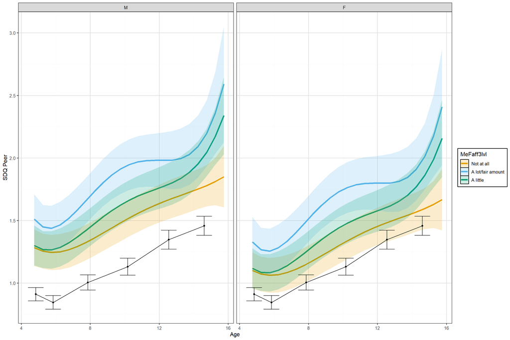

### Covariates sex, income, maternal MH, SIMD

**Estimates**

[1] “No singular fit” [1] “No convergence issues”

| REML |
| --- |
| 42720.5 |

|  | Dsdpr1 |  |  |  |  |  |  |  |  |  |  |
| --- | --- | --- | --- | --- | --- | --- | --- | --- | --- | --- | --- |
| Predictors | Estimates | std. Error | std. Beta | standardized std. Error | CI | standardized CI | Statistic | std. Statistic | p | std. p | df |
| (Intercept) | 1.22 | 0.09 | -0.03 | 0.06 | 1.03 – 1.40 | -0.14 – 0.09 | 12.90 | -0.45 | **<0.001** | 0.653 | 12527.00 |
| age cent | 0.08 | 0.01 | 0.17 | 0.03 | 0.06 – 0.10 | 0.12 – 0.22 | 6.68 | 6.66 | **<0.001** | **<0.001** | 12527.00 |
| MeFaff3lvl [A lot/fair amount] | 0.41 | 0.10 | 0.25 | 0.06 | 0.22 – 0.60 | 0.13 – 0.36 | 4.16 | 4.16 | **<0.001** | **<0.001** | 12527.00 |
| MeFaff3lvl [A little] | 0.14 | 0.07 | 0.09 | 0.04 | 0.01 – 0.27 | 0.01 – 0.16 | 2.17 | 2.16 | **0.030** | **0.030** | 12527.00 |
| age cent^2 | -0.00 | 0.00 | -0.01 | 0.04 | -0.01 – 0.01 | -0.08 – 0.06 | -0.18 | -0.17 | 0.855 | 0.865 | 12527.00 |
| age cent^3 | -0.00 | 0.00 | -0.04 | 0.02 | -0.00 – -0.00 | -0.07 – -0.01 | -2.33 | -2.32 | **0.020** | **0.020** | 12527.00 |
| age cent^4 | 0.00 | 0.00 | 0.02 | 0.02 | -0.00 – 0.00 | -0.02 – 0.05 | 1.02 | 1.02 | 0.310 | 0.310 | 12527.00 |
| Sex [F] | -0.19 | 0.05 | -0.11 | 0.03 | -0.28 – -0.10 | -0.17 – -0.06 | -4.10 | -4.10 | **<0.001** | **<0.001** | 12527.00 |
| DeEqv5 [1] | 0.38 | 0.09 | 0.23 | 0.05 | 0.21 – 0.55 | 0.13 – 0.33 | 4.43 | 4.43 | **<0.001** | **<0.001** | 12527.00 |
| DeEqv5 [2] | 0.20 | 0.08 | 0.12 | 0.05 | 0.05 – 0.35 | 0.03 – 0.21 | 2.55 | 2.55 | **0.011** | **0.011** | 12527.00 |
| DeEqv5 [3] | 0.19 | 0.08 | 0.12 | 0.05 | 0.04 – 0.35 | 0.03 – 0.21 | 2.53 | 2.53 | **0.012** | **0.012** | 12527.00 |
| DeEqv5 [4] | 0.00 | 0.07 | 0.00 | 0.04 | -0.13 – 0.14 | -0.08 – 0.09 | 0.05 | 0.05 | 0.963 | 0.963 | 12527.00 |
| DeSf12mn | -0.18 | 0.02 | -0.11 | 0.01 | -0.23 – -0.14 | -0.14 – -0.08 | -7.95 | -7.95 | **<0.001** | **<0.001** | 12527.00 |
| ALeSNim2 [1] | -0.36 | 0.08 | -0.22 | 0.05 | -0.52 – -0.20 | -0.32 – -0.12 | -4.36 | -4.36 | **<0.001** | **<0.001** | 12527.00 |
| ALeSNim2 [2] | -0.25 | 0.08 | -0.15 | 0.05 | -0.41 – -0.10 | -0.25 – -0.06 | -3.18 | -3.18 | **0.001** | **0.001** | 12527.00 |
| ALeSNim2 [3] | -0.28 | 0.08 | -0.17 | 0.05 | -0.43 – -0.12 | -0.26 – -0.07 | -3.45 | -3.45 | **0.001** | **0.001** | 12527.00 |
| ALeSNim2 [4] | -0.11 | 0.08 | -0.07 | 0.05 | -0.28 – 0.05 | -0.17 – 0.03 | -1.39 | -1.39 | 0.164 | 0.164 | 12527.00 |
| age cent × MeFaff3lvl [A lot/fair amount] | 0.03 | 0.03 | 0.06 | 0.06 | -0.03 – 0.08 | -0.06 – 0.17 | 0.98 | 1.00 | 0.325 | 0.315 | 12527.00 |
| age cent × MeFaff3lvl [A little] | 0.01 | 0.02 | 0.03 | 0.04 | -0.03 – 0.05 | -0.05 – 0.11 | 0.67 | 0.68 | 0.506 | 0.499 | 12527.00 |
| MeFaff3lvl [A lot/fair amount] × age cent^2 | -0.02 | 0.01 | -0.17 | 0.08 | -0.05 – -0.00 | -0.34 – -0.01 | -2.11 | -2.12 | **0.034** | **0.034** | 12527.00 |
| MeFaff3lvl [A little] × age cent^2 | -0.01 | 0.01 | -0.07 | 0.06 | -0.03 – 0.01 | -0.19 – 0.04 | -1.20 | -1.21 | 0.230 | 0.228 | 12527.00 |
| MeFaff3lvl [A lot/fair amount] × age cent^3 | -0.00 | 0.00 | -0.02 | 0.04 | -0.00 – 0.00 | -0.10 – 0.05 | -0.61 | -0.63 | 0.541 | 0.526 | 12527.00 |
| MeFaff3lvl [A little] × age cent^3 | 0.00 | 0.00 | 0.00 | 0.03 | -0.00 – 0.00 | -0.05 – 0.06 | 0.13 | 0.11 | 0.900 | 0.915 | 12527.00 |
| MeFaff3lvl [A lot/fair amount] × age cent^4 | 0.00 | 0.00 | 0.07 | 0.04 | -0.00 – 0.00 | -0.01 – 0.15 | 1.80 | 1.80 | 0.072 | 0.072 | 12527.00 |
| MeFaff3lvl [A little] × age cent^4 | 0.00 | 0.00 | 0.03 | 0.03 | -0.00 – 0.00 | -0.02 – 0.09 | 1.14 | 1.14 | 0.253 | 0.253 | 12527.00 |
| Random Effects |  |  |  |  |  |  |  |  |  |  |  |
| σ<sup>2</sup> | 0.99 |  |  |  |  |  |  |  |  |  |  |
| τ<sub>00</sub> <sub>Idnumber</sub> | 1.05 |  |  |  |  |  |  |  |  |  |  |
| τ<sub>11</sub> <sub>Idnumber.age.cent</sub> | 0.02 |  |  |  |  |  |  |  |  |  |  |
| ρ<sub>01</sub> <sub>Idnumber</sub> | 0.51 |  |  |  |  |  |  |  |  |  |  |
| ICC | 0.56 |  |  |  |  |  |  |  |  |  |  |
| N <sub>Idnumber</sub> | 2118 |  |  |  |  |  |  |  |  |  |  |
| Observations | 12556 |  |  |  |  |  |  |  |  |  |  |
| Marginal R<sup>2</sup> / Conditional R<sup>2</sup> | 0.074 / 0.596 |  |  |  |  |  |  |  |  |  |  |

**Contrasts**

| Age | contrast | null.value | estimate | std.error | df | statistic | p.value |
| --- | --- | --- | --- | --- | --- | --- | --- |
| 4.844 | A little vs Not at all | 0 | 0.019 | 0.065 | 4139.242 | 0.287 | 0.774 |
| 4.844 | A lot/fair amount vs Not at all | 0 | 0.201 | 0.096 | 3422.540 | 2.099 | 0.036 |
| 4.844 | A lot/fair amount vs A little | 0 | 0.182 | 0.100 | 3458.769 | 1.817 | 0.069 |
| 7.863 | A little vs Not at all | 0 | 0.105 | 0.060 | 3942.421 | 1.730 | 0.084 |
| 7.863 | A lot/fair amount vs Not at all | 0 | 0.327 | 0.090 | 3373.939 | 3.615 | 0.000 |
| 7.863 | A lot/fair amount vs A little | 0 | 0.222 | 0.094 | 3447.602 | 2.354 | 0.019 |
| 14.609 | A little vs Not at all | 0 | 0.249 | 0.090 | 2841.127 | 2.759 | 0.006 |
| 14.609 | A lot/fair amount vs Not at all | 0 | 0.376 | 0.135 | 2651.501 | 2.797 | 0.005 |
| 14.609 | A lot/fair amount vs A little | 0 | 0.127 | 0.142 | 2598.539 | 0.894 | 0.371 |

**Plot: Lowest level covariates**

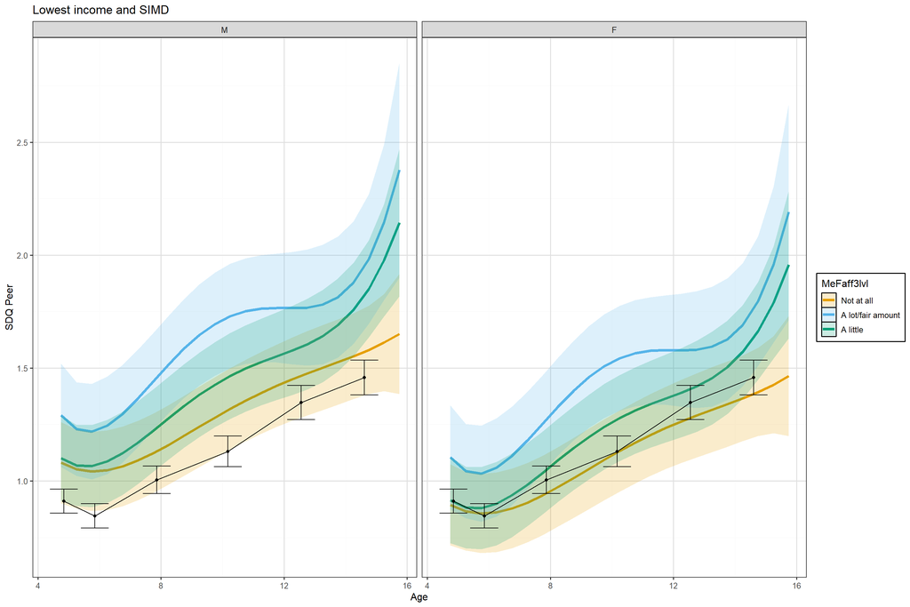

**Plot: Highest level covariates**

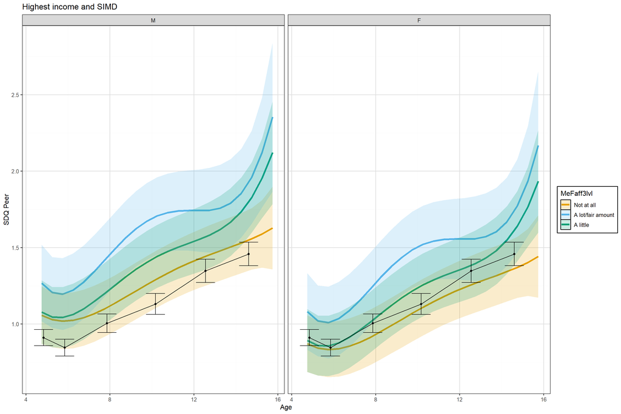